# Projet tourbière

### Etudions la tendance

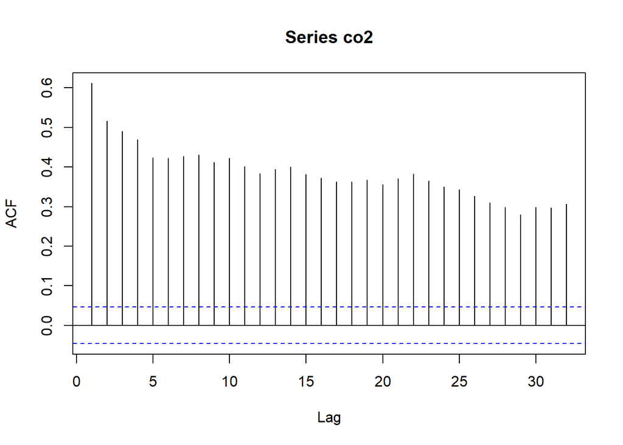

```r
acf(co2)
```

Pour CO2, la décroissance des correlations est lente sur la figure 1.12, ce qui confirme la présence d’une tendance.

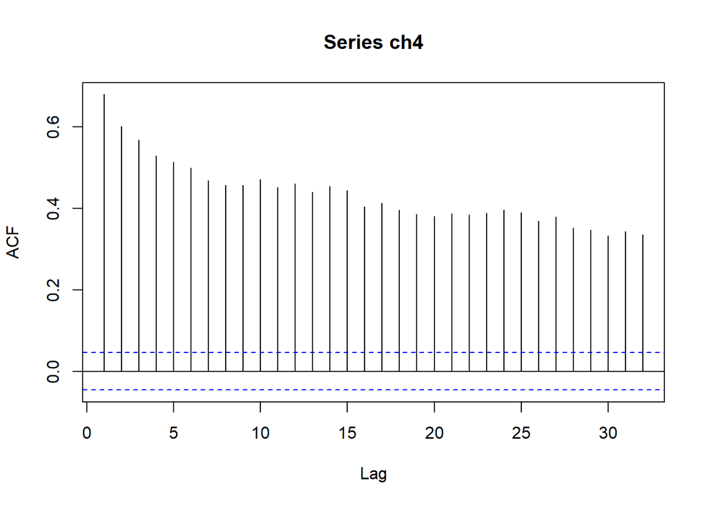

```r
acf(ch4)
```

Pour le CH4, la décroissance des corrélations est lente d’après la figure 1.17, ce qui indique la présence d’une tendance.

### La saisonnalité

Dans head, on a ” Frequency = 365 ” pour les deux séries, donc ce sont des séries journalières avec une saisonnalité annuelle , ce qui est aussi visible sur le graphique de decomposition

Pour plus de detail, on va transformer notre donnée en donnée mensuelle

###### Agrégation par an et par mois

```r
An <- substr(dates, 1, 4)
Mois <- substr(dates, 6, 7)
AnMois <- as.numeric(paste(An, Mois, sep = "")) # Concatène l’année et le mois, sans séparateur, puis                                                       convertit en nombre.
data_mois <- aggregate(df[,-1], by = list(AnMois), FUN = sum) # Agrègeons les colonnes co2 et ch4 par mois, en sommant les valeurs pour chaque

colnames(data_mois)[1] <- "AnMois"
head(data_mois)
```

```
##   AnMois         ETR        FCO2       FCH4      Heat       LHeat SoilHeatd2
## 1 201701 -0.08258203   16.136435 -0.1201289  452.3601   -9.271885  -4.233309
## 2 201702  0.81738164    2.067737 -0.3932979  920.8585  653.477394  37.277286
## 3 201703  1.33525422   -1.973507 -0.5864424 1767.1401 1108.500995  11.772960
## 4 201704  2.33950061  -48.600337 -1.2857656 3762.9002 1929.325538 -87.416484
## 5 201705  3.08442128  -39.046516 -1.2224822 3523.6910 2428.920004 -61.012673
## 6 201706  5.00539111 -116.572877 -1.1276001 2761.2398 3584.727348 -98.072478
##   lgt.bm1_G_1_1_2 lgt.bm1_P_1_1_1 lgt.bm1_PA_1_1_1 lgt.bm1_PPFD_IN_1_1_1
## 1       -11.24751            10.6         13034.19              1792.533
## 2        72.27267            65.4         27969.52              4350.604
## 3        16.37323            95.8         30997.20              7834.721
## 4      -124.10827            18.0         30100.80             12541.020
## 5       -98.37622            83.0         30965.59             12607.164
## 6      -150.44141            65.6         29929.81             12889.179
##   lgt.bm1_RH_1_1_1 lgt.bm1_SWC_1_1_1 lgt.bm1_SWC_1_1_2 lgt.bm1_SWC_1_2_1
```

[output cut: 90 more lines]

#### Examinons maintenant le month plot de CO2 et de CH4

-Pour co2

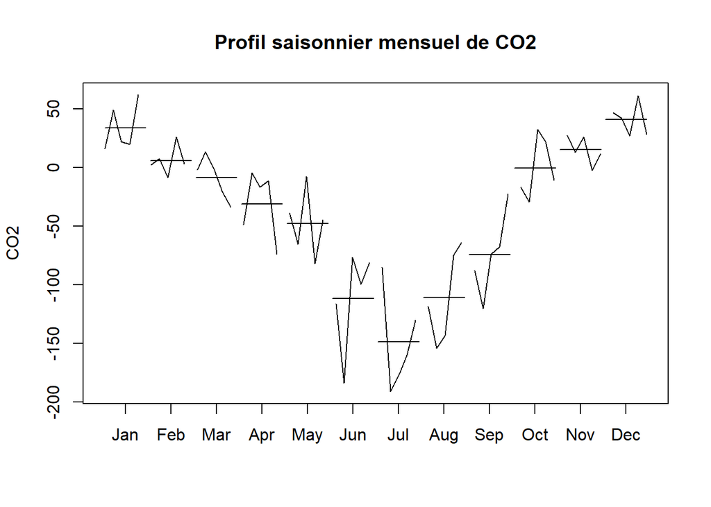

```r
diox <- ts(data_mois[,3], start = c(2017, 1), frequency = 12) # Serie mensuelle de CO2
monthplot(diox, ylab = "CO2",main = "Profil saisonnier mensuel de CO2",labels = substr(month.name,1,3))
```

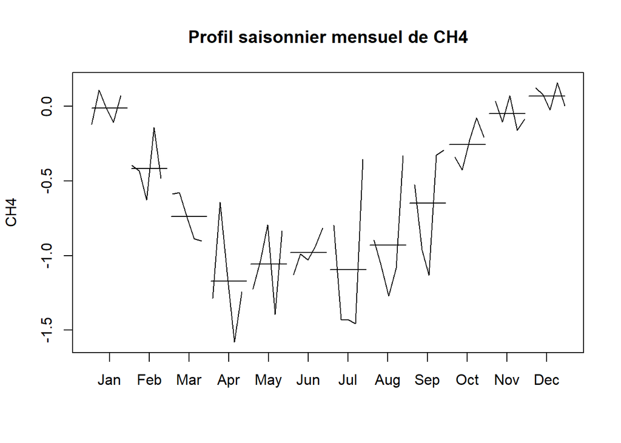

```r
diox <- ts(data_mois[,4], start = c(2017, 1), frequency = 12) # Serie mensuelle de CH4
monthplot(diox, ylab = "CH4",main = "Profil saisonnier mensuel de CH4",labels = substr(month.name,1,3))
```

### La stationarité

moins de detail car ça se fait automatiquement dans auto.arima()

Passons au test de Dickey-Fuller pour verifier la stionnarité sous les hypothèses suivantes :

```
 H0 : il y a une racine unitaire (donc série non stationnaire)
 H1 : la série est stationnaire
```

```r
library(tseries)
adf.test(tco2)
```

```
##
##  Augmented Dickey-Fuller Test
##
## data:  tco2
## Dickey-Fuller = -4.9797, Lag order = 12, p-value = 0.01
## alternative hypothesis: stationary
```

la p-value est inférieure à 0.05 donc on rejette H0, et on peut dire que la série de CO2 n’a pas de racine unitaire, mais on ne peut conclure la stationnarité, car il y’a presence d’une tendance. Et sur le monthplot,par exemple pour le mois de janvier, on observe une fluctuation(une variation du flux de CO2 de chaque année ), donc la covariance va dépendre du temps . Cette contradition peut ètre due à la faiblesse de la variance de la tendance .

```r
adf.test(tch4)
```

```
##
##  Augmented Dickey-Fuller Test
##
## data:  tch4
## Dickey-Fuller = -4.8803, Lag order = 12, p-value = 0.01
## alternative hypothesis: stationary
```

la p-value est inférieure à 0.05 donc on rejette H0, et on peut dire que la série de CH4 n’a pas de racine unitaire, mais on ne peut conclure la stationnarité, car il y’a presence d’une tendance. Et sur le monthplot,par exemple pour le mois de janvier, on observe une fluctuation(une variation du flux de CH4 de chaque année ), donc la covariance va dépendre du temps . Cette contradition peut ètre due à la faiblesse de la variance de la tendance .

## Etape 2 : Stationnarisation

Detail du cours et moins de details car ça se fait automatiquement dans auto.arima

## Etape 3 : Détermination du modèle correspondant au processus de CO2 et CH4 en ajoutant les composantes principales aux quelles ils sont bien correlés comme regrèsseur

Identification du modèle(p,q),Estimation des polynômes P,Q (Confert auto.arima)

## Modèle 1 : Se basant sut tout la série en considérant les phénomènes de 2018,2019…

#### Les données d’entrainement et test

Scindons CO2 et CH4 en 2 données : Données d’entrainement et données test

- Definissons d’abord les regresseurs

```r
rg1<-as.matrix(acp$li[,c(1,3)]) # axe 1,3 comme un regresseur de CO2
rg2<-as.matrix(acp$li[,c(1,3,4)]) # axe 1,3,4 comme un regresseur de CH4 mais CH4 n'est que pas bien correlé avec les axes 1 et 4

tco2 <- as.numeric(tco2)
tco2 <- ts(tco2, frequency = 365, start = c(2017, 19))  # la série commence le 19 Janv 2025

tch4 <- as.numeric(tch4)
tch4 <- ts(tch4, frequency = 365, start = c(2017, 19))
```

#### Train data

```r
# Pour CO2

tco2_train <- window(tco2, end = c(2020, 365))  # co2 train ,données jusqu'a fin 2020
reg1_train<-rg1[1:length(tco2_train),] # regresseur train, données jusqu'a fin 2020

# Pour CH4

tch4_train <- window(tch4, end = c(2020, 365)) # co2 train ,données jusqu'a fin 2020
reg2_train<-rg2[1:length(tch4_train),] # regresseur train, données jusqu'a fin 2020
```

#### Test data

```r
# Pour CO2
tco2_test <- window(tco2, start = c(2021, 1))  # co2 test ,données à partrir de debut 2021
reg1_test <- rg1[(length(tco2_train)+1):(length(tco2_train)+length(tco2_test)), ] ## regresseur test, données à partrir de debut 2021

# Pour CH4
tch4_test <- window(tch4, start = c(2021, 1))  # ch4 test ,données à partrir de debut 2021
reg2_test <- rg2[(length(tch4_train)+1):(length(tch4_train)+length(tch4_test)), ]# regresseur test, données à partrir de debut 2021
```

#### Entrainement en déterminant un modèle(permettant de faire des previsions avec des phénomenes observés)

```r
# pour CO2
mod_co22 <- auto.arima(tco2_train, xreg = reg1_train )
summary(mod_co22)
```

```
## Series: tco2_train
## Regression with ARIMA(4,1,1) errors
##
## Coefficients:
##          ar1    ar2     ar3     ar4      ma1   Axis1   Axis3
##       0.1691  0.029  0.0711  0.0589  -0.9470  0.4343  0.6831
## s.e.  0.0310  0.030  0.0295  0.0292   0.0173  0.0404  0.0256
##
## sigma^2 = 4.051:  log likelihood = -3050
## AIC=6116   AICc=6116.1   BIC=6158.18
##
## Training set error measures:
##                       ME     RMSE      MAE       MPE     MAPE      MASE
## Training set 0.008079491 2.007175 1.392018 -21.73257 363.9474 0.5341945
##                       ACF1
## Training set -0.0005960364
```

Le modèle nous fait savoir que la série de CO2 avec régrèsseurs est différenciée pur être staionnaire .cette non-staionnarité est liée certainement aux régresseurs

```r
# pour CH4
mod_ch44 <- auto.arima(tch4_train, xreg = reg2_train )
summary(mod_ch44)
```

```
## Series: tch4_train
## Regression with ARIMA(1,0,2) errors
##
## Coefficients:
##          ar1      ma1      ma2  intercept  Axis1  Axis3    Axis4
##       0.9493  -0.6811  -0.0963    -0.0206  2e-03  6e-03  -0.0047
## s.e.  0.0149   0.0311   0.0297     0.0012  2e-04  1e-04   0.0002
##
## sigma^2 = 0.0001185:  log likelihood = 4475.65
## AIC=-8935.3   AICc=-8935.2   BIC=-8893.11
##
## Training set error measures:
##                         ME       RMSE         MAE      MPE     MAPE     MASE
## Training set -5.333803e-06 0.01085749 0.007065518 28.07183 137.4635 0.328882
##                      ACF1
## Training set -0.001272294
```

La série de CH4 régressée est toujours stationnaire

#### Analyse des résidus pour valider le modèle

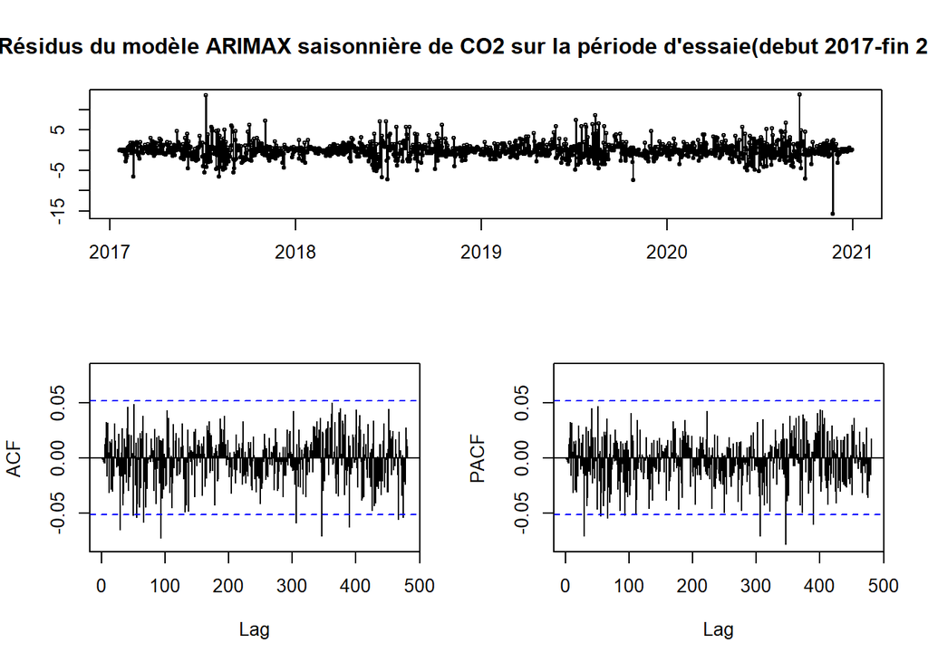

```r
# Pour CO2
tsdisplay(residuals(mod_co22), main ="Résidus du modèle ARIMAX saisonnière de CO2 sur la période d'essaie(debut 2017-fin 2020)")
```

Les autocorrelations ne nous permettent pas d’affirmer clairement que les résidus du modèlé de CO2 sont du bruit blanc à cause du faite que certains sont légèrement sortie de la bande .

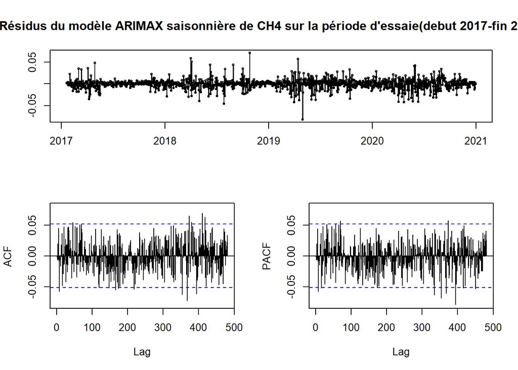

```r
# Pour CH4
tsdisplay(residuals(mod_ch44), main ="Résidus du modèle ARIMAX saisonnière de CH4 sur la période d'essaie(debut 2017-fin 2020)")
```

Les autocorrelations ne nous permettent pas d’affirmer clairement que les résidus du modèlé de CH4 sont du bruit blanc à cause du faite que certains sont légèrement sortie de la bande .

#### Test de blancheur

Faisons un test pour vérifier si les résidus sont du bruit blanc ou pas sous les hypothèses

```
   H0 :"les résidus ne sont pas autocorrélés (→ c’est du bruit blanc)" contre
   H1 :"(alternative) : les résidus sont autocorrélés (→ modèle mal ajusté") au niveau de risque 5%
```

```r
# Pour CO2
Box.test(residuals(mod_co22), lag = 30, type = "Ljung-Box")
```

```
##
##  Box-Ljung test
##
## data:  residuals(mod_co22)
## X-squared = 19.433, df = 30, p-value = 0.9305
```

En ce qui concerne le test de blancheur, la p-valeur est supérieure à alpha(0.05), donc on ne rejette pas HO (les résidus sont du bruit blancs) et donc on peut affirmer que résidus du modèle de CO2 sont du bruit blanc

```r
# Pour CH4
Box.test(residuals(mod_ch44), lag = 30, type = "Ljung-Box")
```

```
##
##  Box-Ljung test
##
## data:  residuals(mod_ch44)
## X-squared = 26.905, df = 30, p-value = 0.6282
```

En ce qui concerne le test de blancheur, la p-valeur est supérieure à alpha(0.05), donc on ne rejette pas HO (les résidus sont du bruit blancs) et donc on peut affirmer que résidus du modèle de CH4 sont du bruit blanc

#### Prévision

```r
library(forecast)
```

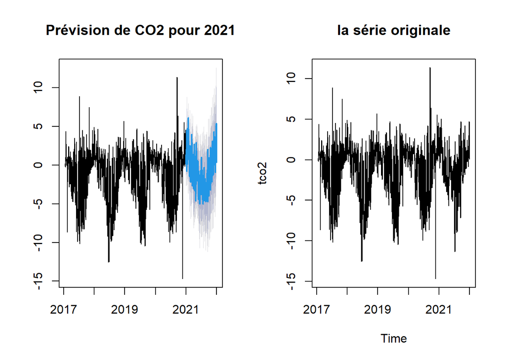

```r
# Prédire CO2 sur 2021

par(mfrow=c(1,2))

pred_co2 <- forecast(mod_co22, h = 365, xreg = reg1_test) # h=365 tout l'année de 2021
plot(pred_co2, main = "Prévision de CO2 pour 2021")
plot(tco2,main="la série originale" )
```

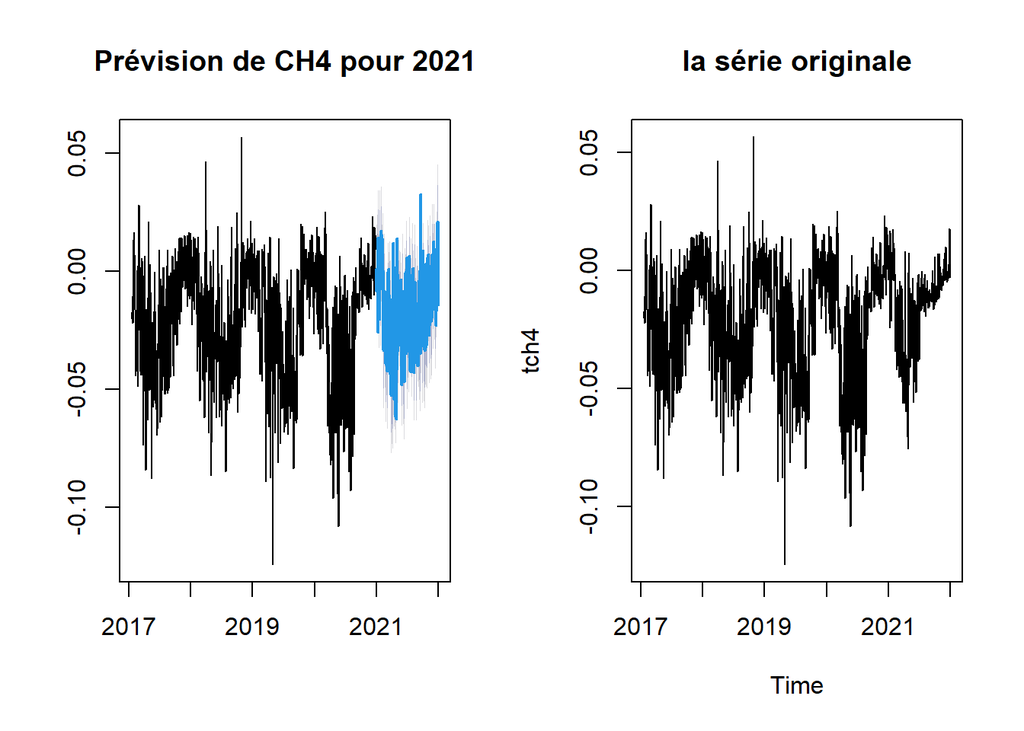

```r
# Prédire CH4 pour 2021

par(mfrow=c(1,2))

pred_ch4 <- forecast(mod_ch44, h = 365, xreg = reg2_test) # h=365 tout l'année de 2021
plot(pred_ch4, main = "Prévision de CH4 pour 2021")
plot(tch4,main="la série originale" )
```

Ces deux nous permettrons de faire une prédiction sur un long horizon en considérant les phénomènes caniculaires et de covid

#### Verifions numériquement si les modèles obtenus sont de bons modèles

##### Pour CO2

```r
mean(tco2); sd(tco2)
```

```
## [1] -1.212604
```

```
## [1] 3.239895
```

```r
accuracy(mod_co22)[, "RMSE"] # racine de l'erreur quadratique moyenne
```

```
## [1] 2.007175
```

```r
accuracy(mod_co22)[, "RMSE"] /sd(tco2)
```

```
## [1] 0.6195186
```

```r
accuracy(mod_co22)[, "RMSE"] /abs(mean(tco2))
```

```
## [1] 1.65526
```

RMSE<Ecart-type : le modèle obtenue pour CO2 explique une part significative de la variabilité Mais RMSE est sensiblement superieure à la moyenne,ce qui indique que le modèle est correct, mais pas très précis.

##### Pour CH4

```r
mean(tch4); sd(tch4)
```

```
## [1] -0.0201321
```

```
## [1] 0.02354836
```

```r
accuracy(mod_ch44)[, "RMSE"] # racine de l'erreur quadratique moyenne
```

```
## [1] 0.01085749
```

```r
accuracy(mod_ch44)[, "RMSE"] /sd(tch4)
```

```
## [1] 0.4610722
```

```r
accuracy(mod_ch44)[, "RMSE"] /abs(mean(tch4))
```

```
## [1] 0.5393124
```

RMSE est inférieure à la moyenne et aussi inférieure à l’écart-type , donc le modèle obteu pour CH4 explique une bonne part de variabilité .

##### Analyse de la prévision sur 2021

-Pour CO2

```r
accuracy(tco2_test,pred_co2$mean)
```

```
##                 ME     RMSE      MAE       MPE     MAPE      ACF1 Theil's U
## Test set 0.2214726 1.721516 1.114809 0.1567243 94.85057 0.5191973 0.5873369
```

MAPE est elevée donc les données surestimées et souestimées sont nombreuses , ce qui montre que la prédiction n’est aussi bonne que ça, mais c’est mieux qu’un modèle naif(répétition de la dernière sur le futur) a cause de (Theil’s U <1)

-Pour CH4

```r
accuracy(tch4_test,pred_ch4$mean)
```

```
##                    ME        RMSE         MAE      MPE    MAPE      ACF1
## Test set -0.002464183 0.009782133 0.007081393 16.62787 91.0725 0.6839007
##          Theil's U
## Test set 0.9580824
```

### Modèle 2 : Se basant uniquement sur les années avant l’année de covid(2020)

- Sur CO2 jusqu’à fin 2019

```r
# Creation de données
tco2_17_19 <- window(tco2, end = c(2019, 365))  # co2 train ,données jusqu'a fin 2018
reg_17_19<-rg1[1:length(tco2_17_19),] # regresseur train, données jusqu'a fin 2018

tco2_20_21 <- window(tco2, start = c(2020, 1))  # co2 test ,données à partrir de debut 2019
reg_20_21 <- rg1[(length(tco2_17_19) + 1):(length(tco2_17_19) + length(tco2_20_21)), ]# regresseur test, données à partrir de debut 2019
```

```r
#Determination du modèle
mod_co2_17_19 <- auto.arima(tco2_17_19, xreg = reg_17_19 )
summary(mod_co2_17_19)
```

```
## Series: tco2_17_19
## Regression with ARIMA(1,1,2) errors
##
## Coefficients:
##          ar1      ma1     ma2   Axis1   Axis3
##       0.7160  -1.4879  0.5143  0.4659  0.6956
## s.e.  0.1789   0.2007  0.1777  0.0550  0.0295
##
## sigma^2 = 3.848:  log likelihood = -2249.98
## AIC=4511.96   AICc=4512.04   BIC=4541.85
##
## Training set error measures:
##                      ME     RMSE      MAE       MPE     MAPE      MASE
## Training set 0.01093882 1.956148 1.371735 -47.38454 416.0245 0.5086019
##                    ACF1
## Training set 0.01633917
```

- Sur CH4 jusqu’à fin 2019

```r
# Creation de données
tch4_17_19 <- window(tch4, end = c(2019,365 )) # co2 train ,données jusqu'a fin 2020
r_17_19<-rg2[1:length(tch4_17_19),] # regresseur train, données jusqu'a fin 2020

tch4_20_21 <- window(tch4, start = c(2020, 1))  # co2 test ,données à partrir de debut 2018
r_20_21 <- rg2[(length(tch4_17_19) + 1):(length(tch4_17_19) + length(tch4_20_21)), ]# regresseur test, données à partrir de debut 2018
```

```r
# pour CH4
mod_ch4_17_19 <- auto.arima(tch4_17_19, xreg = r_17_19 )
summary(mod_ch4_17_19)
```

```
## Series: tch4_17_19
## Regression with ARIMA(2,1,3) errors
##
## Coefficients:
##           ar1     ar2      ma1      ma2     ma3  Axis1   Axis3    Axis4
##       -0.1592  0.7291  -0.6214  -0.9303  0.5804  2e-03  0.0062  -0.0047
## s.e.   0.1001  0.0877   0.1126   0.0298  0.0983  2e-04  0.0002   0.0002
##
## sigma^2 = 0.0001098:  log likelihood = 3381
## AIC=-6744   AICc=-6743.83   BIC=-6699.17
##
## Training set error measures:
##                         ME       RMSE         MAE      MPE    MAPE      MASE
## Training set -1.111041e-05 0.01043659 0.006491715 27.47347 161.641 0.3044104
##                    ACF1
## Training set 0.01068031
```

##### Test de blancheurs sur les residus des modèles avant 2020 retenus

-Pour CO2

```r
Box.test(residuals(mod_co2_17_19), lag = 30, type = "Ljung-Box")
```

```
##
##  Box-Ljung test
##
## data:  residuals(mod_co2_17_19)
## X-squared = 23.491, df = 30, p-value = 0.7945
```

En ce qui concerne le test de blancheur, la p-valeur est supérieure à alpha(0.05), donc on ne rejette pas HO (les résidus sont du bruit blancs) et donc on peut affirmer que résidus du modèle de CO2 sont du bruit blanc

-Pour CH4

```r
Box.test(residuals(mod_ch4_17_19), lag = 30, type = "Ljung-Box")
```

```
##
##  Box-Ljung test
##
## data:  residuals(mod_ch4_17_19)
## X-squared = 30.816, df = 30, p-value = 0.4245
```

##### Faisons une prevision sur 2020-2021

-Pour CO2

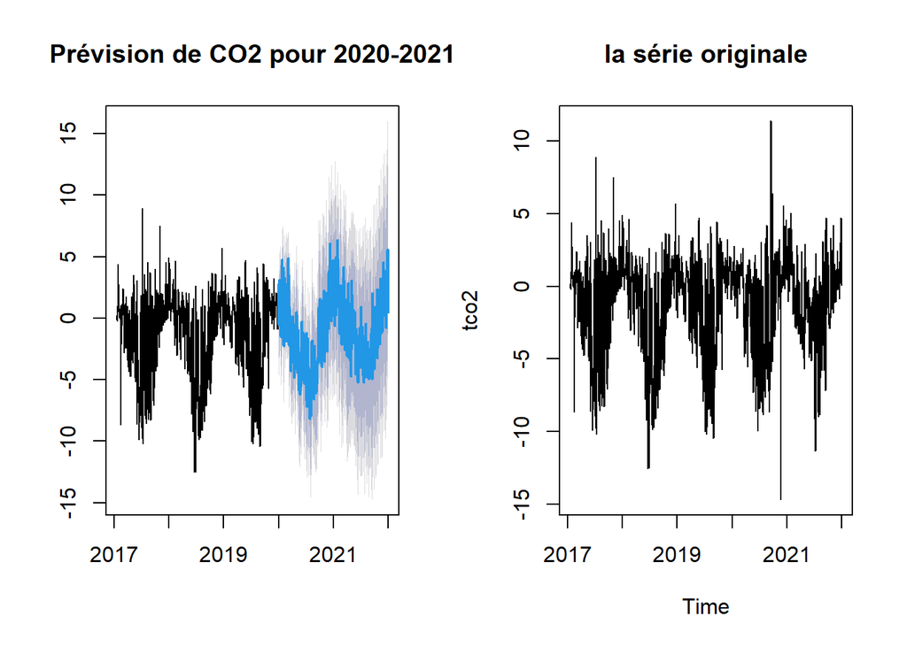

```r
# Prédire CO2 sur 2020-2021

par(mfrow=c(1,2))

pred_co2_20_21 <- forecast(mod_co2_17_19, h = 365*2, xreg =reg_20_21  ) # h=365*4 tout l'année 2019-2021

plot(pred_co2_20_21, main = "Prévision de CO2 pour 2020-2021")
plot(tco2,main="la série originale" )
```

- Pour CH4

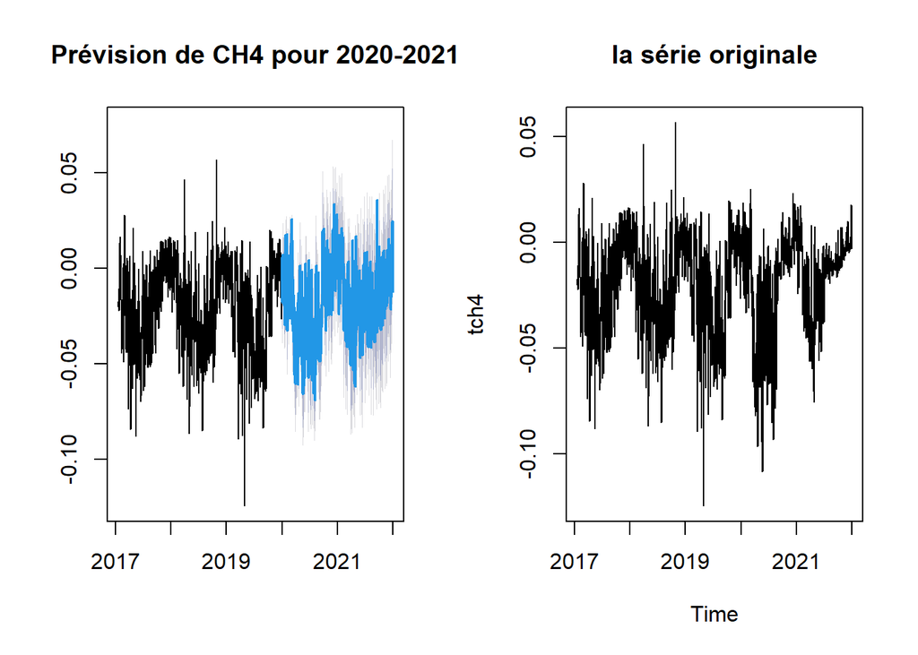

```r
# Prédire CH4 sur 2018-2021

par(mfrow=c(1,2))

pred_ch4_20_21 <- forecast(mod_ch4_17_19, h = 365*2, xreg =r_20_21  ) # toute l'année 2020-2021

plot(pred_ch4_20_21, main = "Prévision de CH4 pour 2020-2021")
plot(tch4,main="la série originale" )
```

Visuellement , on vois que les prévision sont bonne a cause de la dynamique et les saisonnalité qui sont concerver

#### Analysons la qualité de prédiction

```r
accuracy(tco2_20_21,pred_co2_20_21$mean)
```

```
##                  ME     RMSE      MAE      MPE     MAPE      ACF1 Theil's U
## Test set -0.1220508 2.038874 1.355502 8.333917 129.2074 0.3516016 0.9867543
```

L’Erreur Moyenne Absolue en Pourcentage (MAPE) est élévée, ce qui montre qu’on a plus d’erreur que de bonne valeur dans la prediction

(Plus de detail sur MAPE a faire dans le rapport)

```r
accuracy(tch4_20_21,pred_ch4_20_21$mean)
```

```
##                   ME       RMSE         MAE      MPE     MAPE      ACF1
## Test set 0.001243161 0.01265345 0.009102052 26.03262 147.2726 0.5853864
##          Theil's U
## Test set 0.6746526
```

L’Erreur Moyenne Absolue en Pourcentage (MAPE) est un peu élévée, ce qui montre qu’on a un peu d’erreur que de bonne valeur dans la prédiction. Les autres indicateurs montrent que le modèle est bon, mais aussi perfectible.

##### Comparaison des prévisions des deux modèles précédents sur 2021

-CO2

```r
# Extraire les donnees de 2021 uniquement
tco2_2021 <- window(tco2_20_21, start = c(2021, 1), end = c(2021, 365))
pred_co2_2021 <- window(pred_co2_20_21$mean, start = c(2021, 1), end = c(2021, 365))

accuracy(tco2_2021, pred_co2_2021)
```

```
##                 ME    RMSE      MAE       MPE     MAPE      ACF1 Theil's U
## Test set 0.2212157 1.75359 1.171426 -5.339274 95.60096 0.5375284 0.9491012
```

-CH4

```r
tch4_2021 <- window(tch4_20_21, start = c(2021, 1), end = c(2021, 365))
pred_ch4_2021 <- window(pred_ch4_20_21$mean, start = c(2021, 1), end = c(2021, 365))

accuracy(tch4_2021, pred_ch4_2021)
```

```
##                     ME        RMSE         MAE      MPE     MAPE      ACF1
## Test set -0.0004015075 0.009654343 0.007472967 21.13917 108.8785 0.6779191
##          Theil's U
## Test set 0.4004546
```

#### Modèle 3 : Sans regresseurs

-Training set

```r
# Pour CO2
tco2_train <- window(tco2, end = c(2020, 365))  # co2 train ,données jusqu'a fin 2020


# Pour CH4
tch4_train <- window(tch4, end = c(2020, 365)) # co2 train ,données jusqu'a fin 2020
```

-Test set

```r
# Pour CO2
tco2_test <- window(tco2, start = c(2021, 1))  # co2 test ,données à partrir de debut 2021

# Pour CH4
tch4_test <- window(tch4, start = c(2021, 1))  # ch4 test ,données à partrir de debut 2021
```

-Modelisation

```r
# pour CO2
mod_co2_sr <- auto.arima(tco2_train )
summary(mod_co2_sr)
```

```
## Series: tco2_train
## ARIMA(2,0,1) with zero mean
##
## Coefficients:
##          ar1      ar2      ma1
##       1.2089  -0.2183  -0.8694
## s.e.  0.0353   0.0337   0.0212
##
## sigma^2 = 6.167:  log likelihood = -3356.97
## AIC=6721.95   AICc=6721.97   BIC=6743.04
##
## Training set error measures:
##                       ME     RMSE     MAE      MPE     MAPE      MASE
## Training set -0.08244551 2.480834 1.75013 50.81721 335.8661 0.6716219
##                      ACF1
## Training set -0.005145006
```

Le modèle de CO2 sans regresseur est stationnaire. Mais on remarque que les critères, et l’erreur moyenne en poucentage (MAPE) sont très élevées, donc ce modèle ne capte pas la dynamique du flux de CO2

```r
# pour CH4
mod_ch4_sr <- auto.arima(tch4_train )
summary(mod_ch4_sr)
```

```
## Series: tch4_train
## ARIMA(4,0,1) with non-zero mean
##
## Coefficients:
##          ar1      ar2     ar3      ar4      ma1     mean
##       1.2870  -0.2342  0.0015  -0.0623  -0.9002  -0.0212
## s.e.  0.0353   0.0437  0.0429   0.0292   0.0229   0.0054
##
## sigma^2 = 0.0002945:  log likelihood = 3818.12
## AIC=-7622.25   AICc=-7622.17   BIC=-7585.33
##
## Training set error measures:
##                        ME       RMSE        MAE      MPE     MAPE      MASE
## Training set 7.331889e-05 0.01712617 0.01282145 42.54727 282.6952 0.5968061
##                      ACF1
## Training set 0.0003843698
```

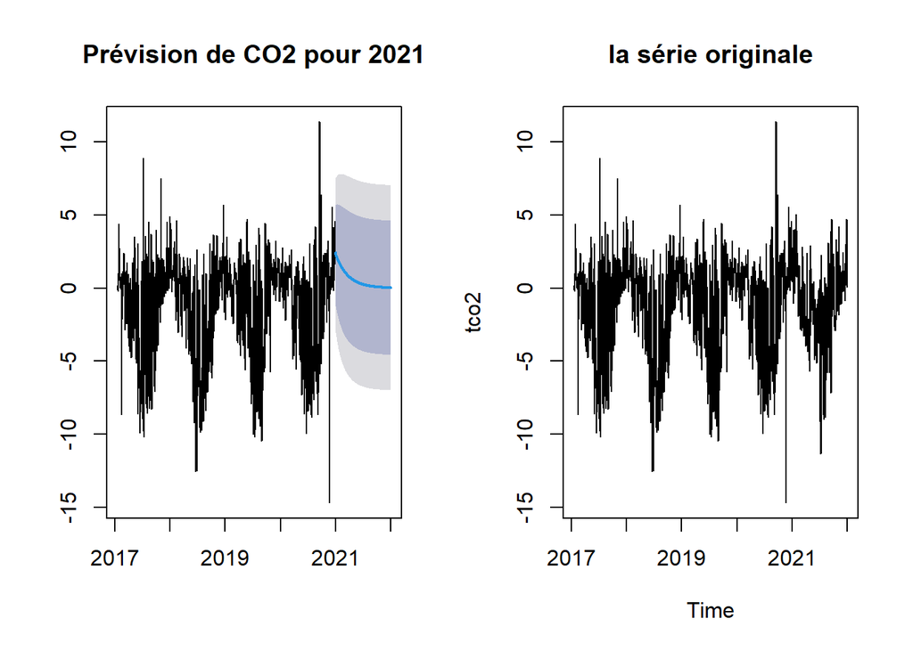

```r
# Prédire CO2 sur 2021

par(mfrow=c(1,2))

pred_co2_sr <- forecast(mod_co2_sr, h = 365) # h=365 toute l'année de 2021
plot(pred_co2_sr, main = "Prévision de CO2 pour 2021")
plot(tco2,main="la série originale" )
```

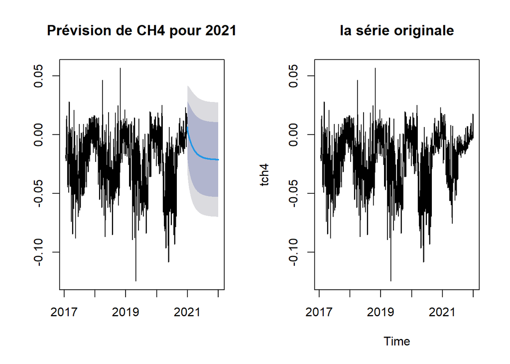

```r
# Prédire CH4 pour 2021

par(mfrow=c(1,2))

pred_ch4_sr <- forecast(mod_ch4_sr, h = 365, xreg = reg2_test) # h=365 tout l'année de 2021
plot(pred_ch4_sr, main = "Prévision de CH4 pour 2021")
plot(tch4,main="la série originale" )
```

# Analysons la qualité de prediction sur 2021, du modèle sans regresseur

-Pour CO2

```r
accuracy(tco2_test,pred_co2_sr$mean)
```

```
##                ME     RMSE      MAE      MPE     MAPE      ACF1 Theil's U
## Test set 1.501395 2.966081 2.199363 313.9613 1292.679 0.6294474  1728.967
```

-Pour CH4

```r
accuracy(tch4_test,pred_ch4_sr$mean)
```

```
##                    ME       RMSE        MAE      MPE     MAPE      ACF1
## Test set -0.001254271 0.01851504 0.01540639 17.82594 197.3361 0.7928543
##          Theil's U
## Test set   23.8364
```

Ici, les Theil’s U des previsions de CO2 et CH2 sont très élevées par rapport aux modèle avec regresseurs, donc les modèles avec regresseurs sont mieux .

#### Superposition des données prédites sur les observées des deux premières modèles

###### Prévision sur 2020-2021

- Pour CO2

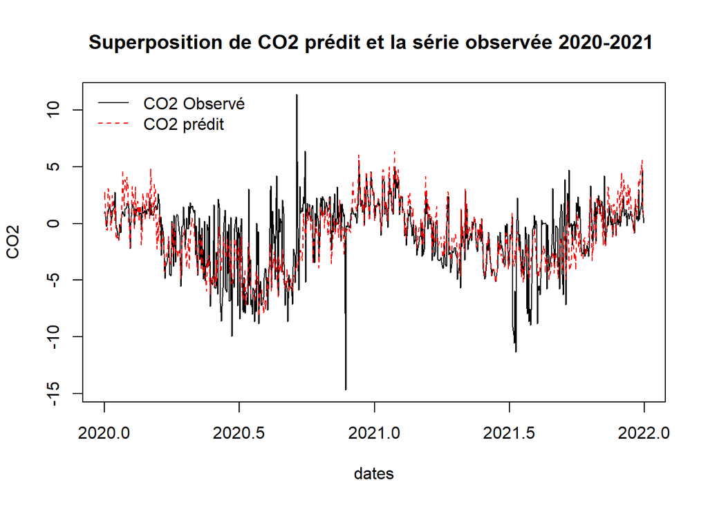

```r
tco2_20_21 <- window(tco2, start = c(2020, 1))
matrix_1<-cbind(tco2_20_21,pred_co2_20_21$mean) #,pred_co2_19_21$upper,pred_co2_19_21$lower)

plot(matrix_1,
     plot.type = "single",
     lty = c(1,2),          # Types de lignes : continue, pointillée, pointillée
     col = c("black","red"),  # Couleurs : original, borne inférieure, borne supérieure
     xlab = "dates",
     ylab = "CO2",
     main = "Superposition de CO2 prédit et la série observée 2020-2021 ",
     cex.main = 1.2)

legend(par("usr")[1],par("usr")[4],
       legend = c("CO2 Observé","CO2 prédit"),
       col = c("black","red"),
       lty = c(1,2),lwd=1,
       bty = "n")
```

On voit ici que la superposistion n’est pas bien faite.Donc sans les chiffres, on peut dire que la prévision n’est pas bonne avec ce modèle .

-Pour CH4

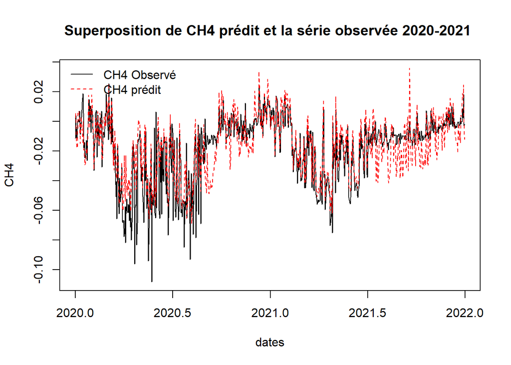

```r
tch4_20_21 <- window(tch4, start = c(2020, 1))
matrix_2<-cbind(tch4_20_21,pred_ch4_20_21$mean) #,pred_co2_19_21$upper,pred_co2_19_21$lower)

plot(matrix_2,
     plot.type = "single",
     lty = c(1,2),          # Types de lignes : continue, pointillée, pointillée
     col = c("black","red"),  # Couleurs : original, borne inférieure, borne supérieure
     xlab = "dates",
     ylab = "CH4",
     main = "Superposition de CH4 prédit et la série observée 2020-2021 ",
     cex.main = 1.2)

legend(par("usr")[1],par("usr")[4],
       legend = c("CH4 Observé","CH4 prédit"),
       col = c("black","red"),
       lty = c(1,2),lwd=1,
       bty = "n")
```

Ici aussi, on voit que la superposistion n’est pas bien faite.Donc sans les chiffres, on peut dire que la prévision n’est pas bonne avec ce modèle et ça ce fait plus remarqué en 2021 .

###### Prévision sur 2021

- Pour CO2

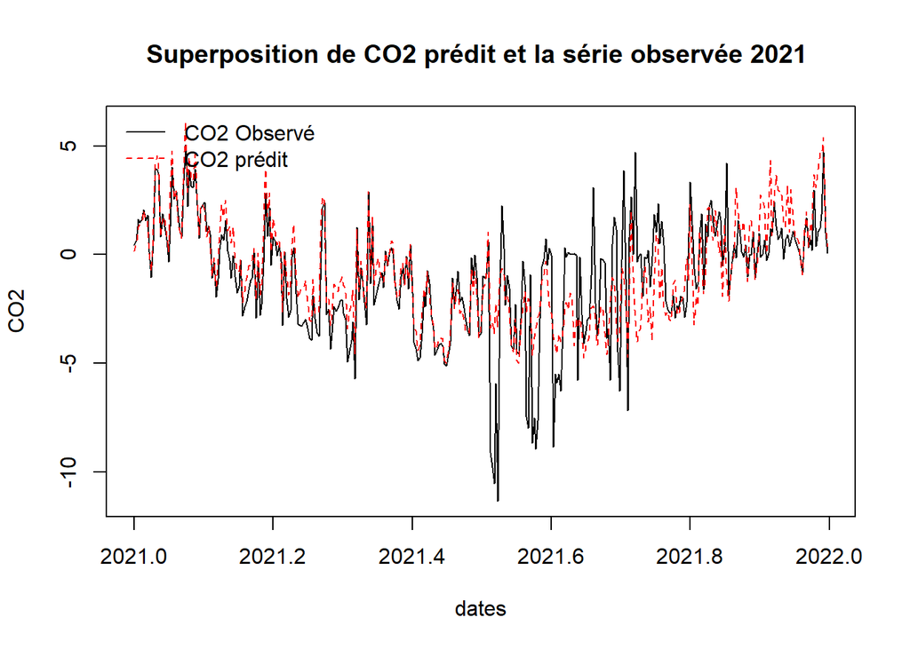

```r
tco2_21 <- window(tco2, start = c(2021, 1))
matrix_3<-cbind(tco2_21,pred_co2$mean) #,pred_co2_19_21$upper,pred_co2_19_21$lower)

plot(matrix_3,
     plot.type = "single",
     lty = c(1,2),          # Types de lignes : continue, pointillée, pointillée
     col = c("black","red"),  # Couleurs : original, borne inférieure, borne supérieure
     xlab = "dates",
     ylab = "CO2",
     main = "Superposition de CO2 prédit et la série observée 2021 ",
     cex.main = 1.2)

legend(par("usr")[1],par("usr")[4],
       legend = c("CO2 Observé","CO2 prédit"),
       col = c("black","red"),
       lty = c(1,2),lwd=1,
       bty = "n")
```

La prévision de CO2 de ce modèle(2017-2020) semble être mieux sur 2021 que celle du modèle(2017-2019). Mais n’est pas bien superposé

-Pour CH4

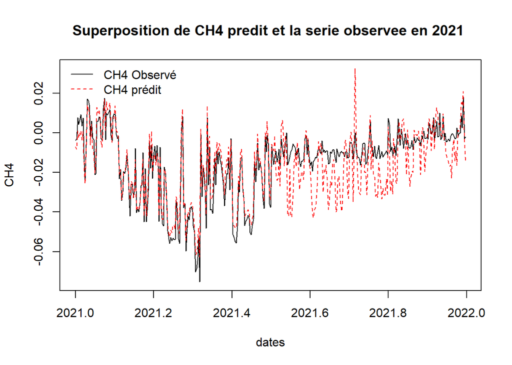

```r
tch4_21 <- window(tch4, start = c(2021, 1))
matrix_4<-cbind(tch4_21,pred_ch4$mean) #,pred_co2_19_21$upper,pred_co2_19_21$lower)

plot(matrix_4,
     plot.type = "single",
     lty = c(1,2),          # Types de lignes : continue, pointillée, pointillée
     col = c("black","red"),  # Couleurs : original, borne inférieure, borne supérieure
     xlab = "dates",
     ylab = "CH4",
     main = "Superposition de CH4 predit et la serie observee en 2021 ",
     cex.main = 1.2)

legend(par("usr")[1],par("usr")[4],
       legend = c("CH4 Observé","CH4 prédit"),
       col = c("black","red"),
       lty = c(1,2),lwd=1,
       bty = "n")
```

Voyant ça,on remarque que la superposition n’est toujours pas bien faite, et il semble que ce modèle est pire que celui conçu sur 2017-2019

### Modèle 4 : Se basant uniquement sur les années avant l’année de secheresse(2019)

-CO2

```r
# Creation de données
tco2_17_18 <- window(tco2, end = c(2018, 365))  # co2 train ,données jusqu'a fin 2018
reg1_17_18<-rg1[1:length(tco2_17_18),] # regresseur train, données jusqu'a fin 2018

tco2_19_21 <- window(tco2, start = c(2019, 1))  # co2 test ,données à partrir de debut 2019
reg1_19_21 <- rg1[(length(tco2_17_18) + 1):(length(tco2_17_18) + length(tco2_19_21)), ]# regresseur test, données à partrir de debut 2019
```

```r
#Determination du modèle
mod_co2_17_18 <- auto.arima(tco2_17_18, xreg = reg1_17_18 )
summary(mod_co2_17_18)
```

```
## Series: tco2_17_18
## Regression with ARIMA(1,0,1) errors
##
## Coefficients:
##          ar1      ma1  intercept   Axis1   Axis3
##       0.8927  -0.7139    -1.5140  0.4233  0.6977
## s.e.  0.0421   0.0644     0.1947  0.0365  0.0355
##
## sigma^2 = 3.879:  log likelihood = -1490.53
## AIC=2993.06   AICc=2993.18   BIC=3020.47
##
## Training set error measures:
##                       ME     RMSE      MAE       MPE     MAPE      MASE
## Training set 0.002055175 1.962668 1.361386 -93.72513 356.9494 0.4776065
##                    ACF1
## Training set 0.01566117
```

Test de blancheur des residus

```r
Box.test(residuals(mod_co2_17_18), lag = 30, type = "Ljung-Box")
```

```
##
##  Box-Ljung test
##
## data:  residuals(mod_co2_17_18)
## X-squared = 23.594, df = 30, p-value = 0.7901
```

-CH4

```r
# Creation de données
tch4_17_18 <- window(tch4, end = c(2018,365 )) # co2 train
reg2_17_18<-rg2[1:length(tch4_17_18),] # regresseur train,

tch4_19_21 <- window(tch4, start = c(2019, 1))  # co2 test ,données à partrir de debut 2018
reg2_19_21 <- rg2[(length(tch4_17_18) + 1):(length(tch4_17_18) + length(tch4_19_21)), ]# regresseur test, données à partrir de debut 2018
```

```r
# pour CH4
mod_ch4_17_18 <- auto.arima(tch4_17_18, xreg = reg2_17_18 )
summary(mod_ch4_17_18)
```

```
## Series: tch4_17_18
## Regression with ARIMA(1,1,2) errors
##
## Coefficients:
##          ar1      ma1     ma2   Axis1   Axis3    Axis4
##       0.7444  -1.5245  0.5432  0.0024  0.0063  -0.0049
## s.e.  0.1089   0.1260  0.1164  0.0003  0.0002   0.0002
##
## sigma^2 = 9.389e-05:  log likelihood = 2290.01
## AIC=-4566.02   AICc=-4565.86   BIC=-4534.06
##
## Training set error measures:
##                        ME     RMSE         MAE        MPE     MAPE     MASE
## Training set 5.334088e-05 0.009642 0.005790152 -0.6683113 158.1447 0.259855
##                    ACF1
## Training set 0.01398772
```

Test de blancheur de residus

```r
Box.test(residuals(mod_ch4_17_18), lag = 30, type = "Ljung-Box")
```

```
##
##  Box-Ljung test
##
## data:  residuals(mod_ch4_17_18)
## X-squared = 37.181, df = 30, p-value = 0.1719
```

Prevision

-CO2

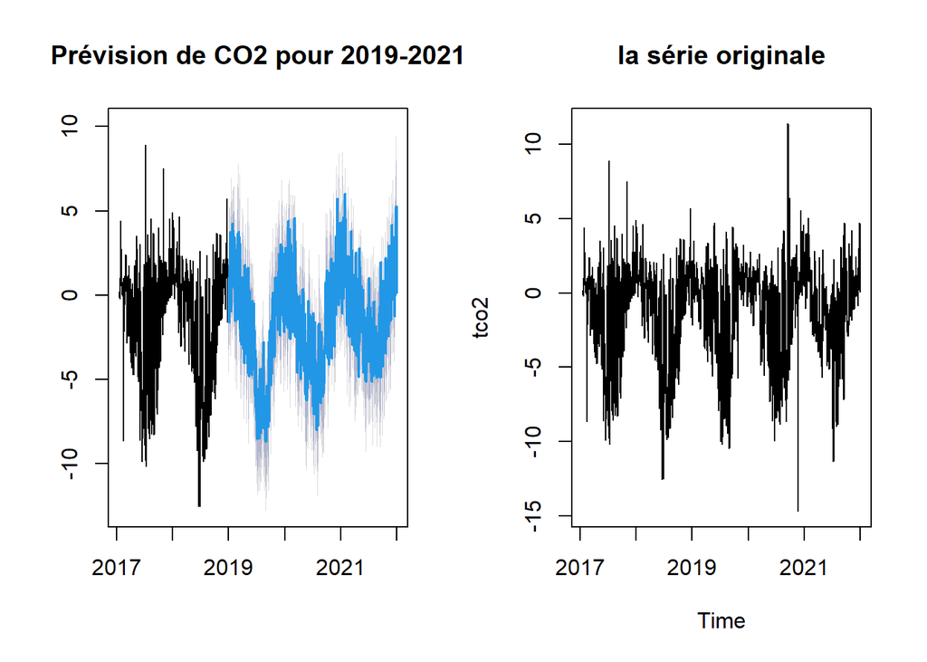

```r
# Prédire CO2 sur 2019-2021

par(mfrow=c(1,2))

pred_co2_19_21 <- forecast(mod_co2_17_18, h = 365*3, xreg =reg1_19_21  ) # h=365*4 tout l'année 2019-2021

plot(pred_co2_19_21, main = "Prévision de CO2 pour 2019-2021")
plot(tco2,main="la série originale" )
```

-CH4

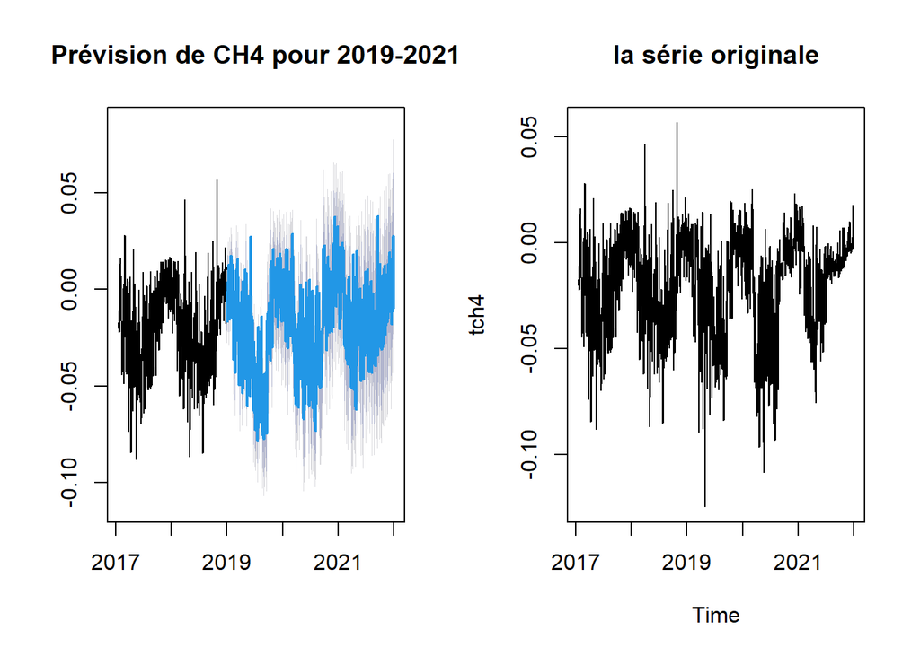

```r
# Prédire CH4 sur 2019-2021

par(mfrow=c(1,2))

pred_ch4_19_21 <- forecast(mod_ch4_17_18, h = 365*3, xreg =reg2_19_21  ) # h=365*4 tout l'année 2019-2021

plot(pred_ch4_19_21, main = "Prévision de CH4 pour 2019-2021")
plot(tch4,main="la série originale" )
```

##### Qualité de prevision

```r
accuracy(tco2_19_21,pred_co2_19_21$mean)
```

```
##                  ME     RMSE      MAE      MPE     MAPE      ACF1 Theil's U
## Test set -0.4942351 2.181528 1.486079 101.5732 201.8137 0.4005187 0.3482057
```

```r
accuracy(tch4_19_21,pred_ch4_19_21$mean)
```

```
##                  ME       RMSE         MAE      MPE     MAPE     ACF1 Theil's U
## Test set 0.00147834 0.01317419 0.009534287 134.8674 279.5393 0.518359 0.2404529
```

#### Superposition des données prédites sur les observées de tout les modèles sauf sans regresseur

###### Prévision sur 2019-2021

- Pour CO2

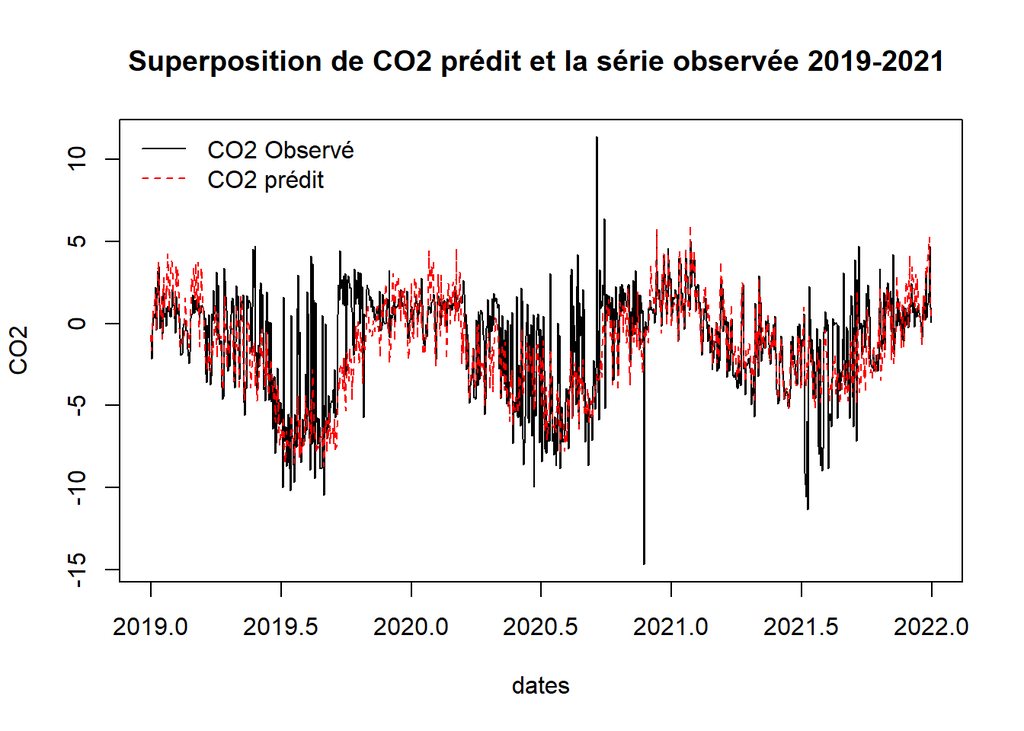

```r
tco2_19_21 <- window(tco2, start = c(2019, 1))
matrix_7<-cbind(tco2_19_21,pred_co2_19_21$mean) #,pred_co2_19_21$upper,pred_co2_19_21$lower)

plot(matrix_7,
     plot.type = "single",
     lty = c(1,2),          # Types de lignes : continue, pointillée, pointillée
     col = c("black","red"),  # Couleurs : original, borne inférieure, borne supérieure
     xlab = "dates",
     ylab = "CO2",
     main = "Superposition de CO2 prédit et la série observée 2019-2021 ",
     cex.main = 1.2)

legend(par("usr")[1],par("usr")[4],
       legend = c("CO2 Observé","CO2 prédit"),
       col = c("black","red"),
       lty = c(1,2),lwd=1,
       bty = "n")
```

-Pour CH4

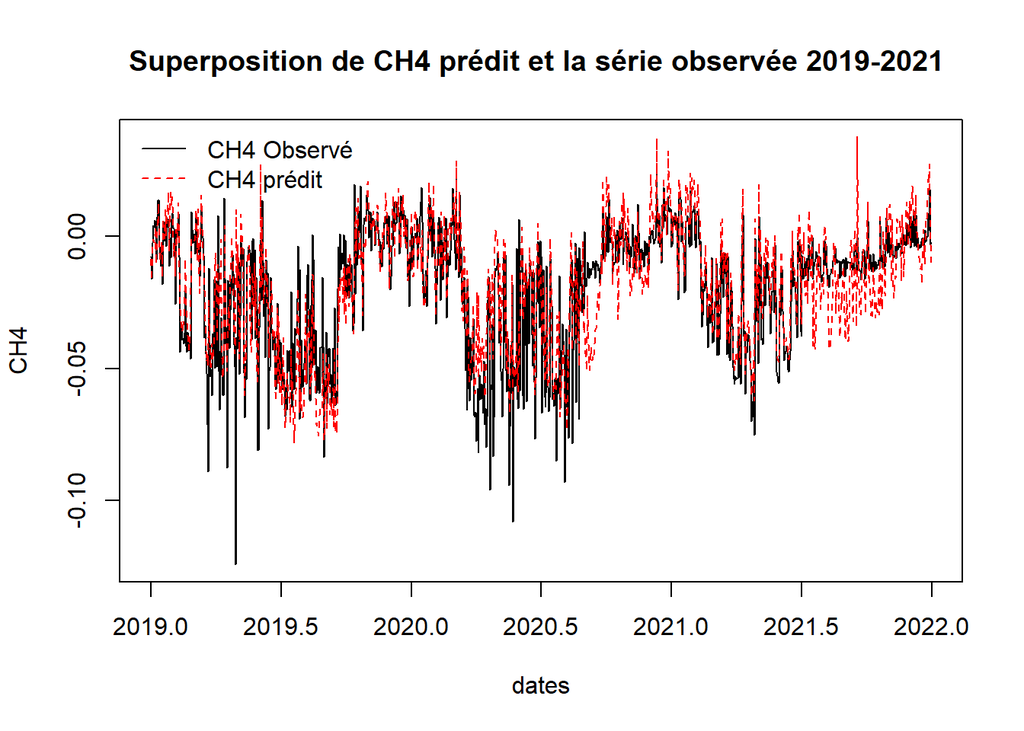

```r
tch4_20_21 <- window(tch4, start = c(2019, 1))
matrix_8<-cbind(tch4_19_21,pred_ch4_19_21$mean) #,pred_co2_19_21$upper,pred_co2_19_21$lower)

plot(matrix_8,
     plot.type = "single",
     lty = c(1,2),          # Types de lignes : continue, pointillée, pointillée
     col = c("black","red"),  # Couleurs : original, borne inférieure, borne supérieure
     xlab = "dates",
     ylab = "CH4",
     main = "Superposition de CH4 prédit et la série observée 2019-2021 ",
     cex.main = 1.2)

legend(par("usr")[1],par("usr")[4],
       legend = c("CH4 Observé","CH4 prédit"),
       col = c("black","red"),
       lty = c(1,2),lwd=1,
       bty = "n")
```

###### Prévision sur 2021

- Pour CO2

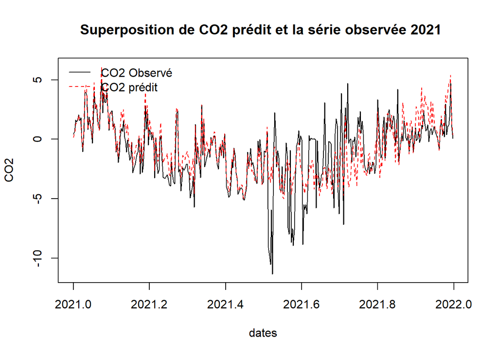

```r
tco2_21 <- window(tco2, start = c(2021, 1))
matrix_9<-cbind(tco2_21,pred_co2$mean) #,pred_co2_19_21$upper,pred_co2_19_21$lower)

plot(matrix_9,
     plot.type = "single",
     lty = c(1,2),          # Types de lignes : continue, pointillée, pointillée
     col = c("black","red"),  # Couleurs : original, borne inférieure, borne supérieure
     xlab = "dates",
     ylab = "CO2",
     main = "Superposition de CO2 prédit et la série observée 2021 ",
     cex.main = 1.2)

legend(par("usr")[1],par("usr")[4],
       legend = c("CO2 Observé","CO2 prédit"),
       col = c("black","red"),
       lty = c(1,2),lwd=1,
       bty = "n")
```

-Pour CH4

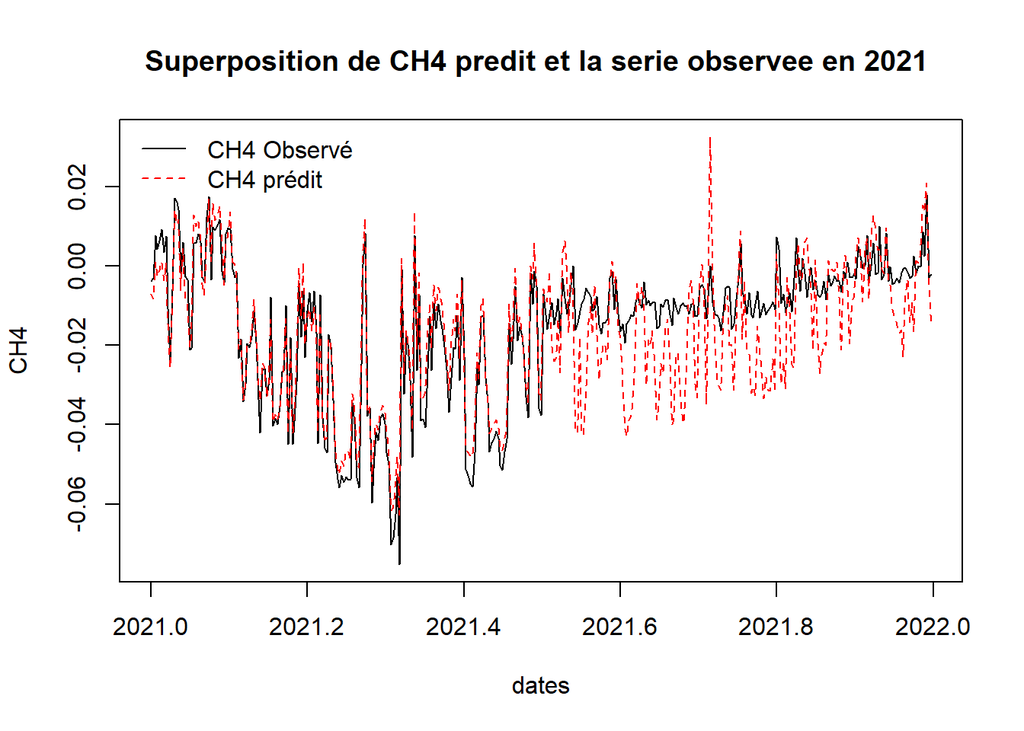

```r
tch4_21 <- window(tch4, start = c(2021, 1))
matrix_10<-cbind(tch4_21,pred_ch4$mean) #,pred_co2_19_21$upper,pred_co2_19_21$lower)

plot(matrix_10,
     plot.type = "single",
     lty = c(1,2),          # Types de lignes : continue, pointillée, pointillée
     col = c("black","red"),  # Couleurs : original, borne inférieure, borne supérieure
     xlab = "dates",
     ylab = "CH4",
     main = "Superposition de CH4 predit et la serie observee en 2021 ",
     cex.main = 1.2)

legend(par("usr")[1],par("usr")[4],
       legend = c("CH4 Observé","CH4 prédit"),
       col = c("black","red"),
       lty = c(1,2),lwd=1,
       bty = "n")
```

###### Prévision sur 2019-2021

- Pour CO2

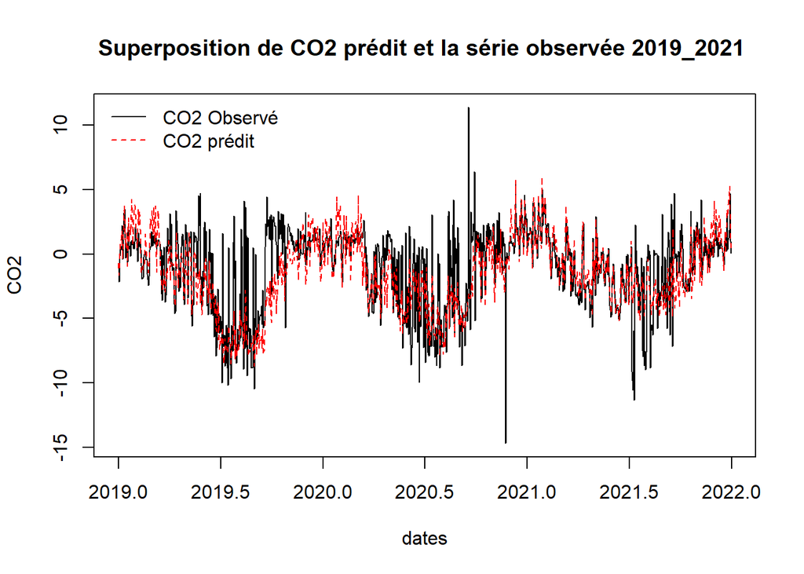

```r
tco2_19_21 <- window(tco2, start = c(2019, 1))
matrix_11<-cbind(tco2_19_21,pred_co2_19_21$mean) #,pred_co2_19_21$upper,pred_co2_19_21$lower)

plot(matrix_11,
     plot.type = "single",
     lty = c(1,2),          # Types de lignes : continue, pointillée, pointillée
     col = c("black","red"),  # Couleurs : original, borne inférieure, borne supérieure
     xlab = "dates",
     ylab = "CO2",
     main = "Superposition de CO2 prédit et la série observée 2019_2021 ",
     cex.main = 1.2)

legend(par("usr")[1],par("usr")[4],
       legend = c("CO2 Observé","CO2 prédit"),
       col = c("black","red"),
       lty = c(1,2),lwd=1,
       bty = "n")
```

Avec ce modèle, la prévision semble mieux capter la fluctuation de CO2, surtout en 2021, que les précédantes

-Pour CH4

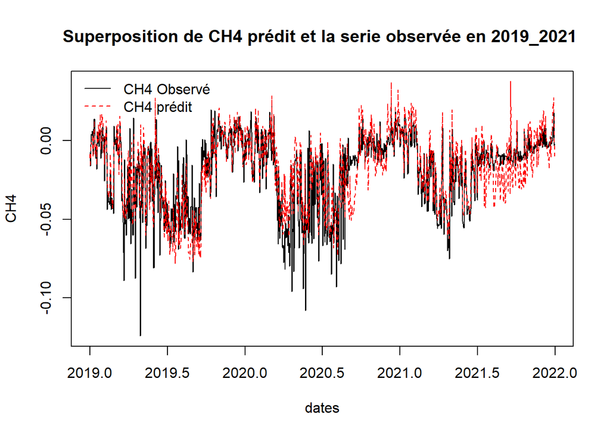

```r
tch4_19_21 <- window(tch4, start = c(2019, 1))
matrix_12<-cbind(tch4_19_21,pred_ch4_19_21$mean) #,pred_co2_19_21$upper,pred_co2_19_21$lower)

plot(matrix_12,
     plot.type = "single",
     lty = c(1,2),          # Types de lignes : continue, pointillée, pointillée
     col = c("black","red"),  # Couleurs : original, borne inférieure, borne supérieure
     xlab = "dates",
     ylab = "CH4",
     main = "Superposition de CH4 prédit et la serie observée en 2019_2021 ",
     cex.main = 1.2)

legend(par("usr")[1],par("usr")[4],
       legend = c("CH4 Observé","CH4 prédit"),
       col = c("black","red"),
       lty = c(1,2),lwd=1,
       bty = "n")
```

Pour ce modèle, sa prévision semble mieux capter le flux de CH4 que les derniers.

##### Voyons maintenant la qualité sur de prevision des 3 modèles sur 2021

Pour le modèle de 2017-2020

-Pour CO2

```r
accuracy(tco2_test,pred_co2$mean)
```

```
##                 ME     RMSE      MAE       MPE     MAPE      ACF1 Theil's U
## Test set 0.2214726 1.721516 1.114809 0.1567243 94.85057 0.5191973 0.5873369
```

-Pour CH4

```r
accuracy(tch4_test,pred_ch4$mean)
```

```
##                    ME        RMSE         MAE      MPE    MAPE      ACF1
## Test set -0.002464183 0.009782133 0.007081393 16.62787 91.0725 0.6839007
##          Theil's U
## Test set 0.9580824
```

Pour le modèle de 2017-2019

-CO2

```r
# Extraire les donnees de 2021 uniquement
tco2_21 <- window(tco2_19_21, start = c(2021, 1), end = c(2021, 365))
pred_co2_2021 <- window(pred_co2_20_21$mean, start = c(2021, 1), end = c(2021, 365))

accuracy(tco2_21, pred_co2_2021)
```

```
##                 ME    RMSE      MAE       MPE     MAPE      ACF1 Theil's U
## Test set 0.2212157 1.75359 1.171426 -5.339274 95.60096 0.5375284 0.9491012
```

-CH4

```r
tch4_2021 <- window(tch4_19_21, start = c(2021, 1), end = c(2021, 365))
pred_ch4_2021 <- window(pred_ch4_20_21$mean, start = c(2021, 1), end = c(2021, 365))

accuracy(tch4_2021, pred_ch4_2021)
```

```
##                     ME        RMSE         MAE      MPE     MAPE      ACF1
## Test set -0.0004015075 0.009654343 0.007472967 21.13917 108.8785 0.6779191
##          Theil's U
## Test set 0.4004546
```

Pour le modèle de 2017-2018

-CO2

```r
# Extraire les donnees de 2021 uniquement
tco2_21 <- window(tco2_19_21, start = c(2021, 1), end = c(2021, 365))
pred_co2_2021 <- window(pred_co2_19_21$mean, start = c(2021, 1), end = c(2021, 365))

accuracy(tco2_21, pred_co2_2021)
```

```
##                  ME     RMSE      MAE      MPE     MAPE     ACF1 Theil's U
## Test set 0.03388455 1.699483 1.085914 15.13054 81.36274 0.512154 0.3855909
```

-CH4

```r
tch4_21 <- window(tch4_19_21, start = c(2021, 1), end = c(2021, 365))
pred_ch4_2021 <- window(pred_ch4_19_21$mean, start = c(2021, 1), end = c(2021, 365))

accuracy(tch4_21, pred_ch4_2021)
```

```
##                  ME       RMSE         MAE      MPE     MAPE      ACF1
## Test set 0.00103482 0.01021708 0.008158019 91.37772 174.0714 0.6922782
##          Theil's U
## Test set 0.3884068
```

# Détermination du modèle correspondant au processus de CO2 et CH4 en ajoutant les quatres composantes principales comme regrèsseur

## Modèle 1 : Se basant sut tout la série en considérant les phénomènes de 2018,2019…

#### Les données d’entrainement et test

Scindons CO2 et CH4 en 2 données : Données d’entrainement et données test

- Definissons d’abord les regresseurs

```r
rg1<-as.matrix(acp$li[,c(1,2,3,4)]) # axe 1,2,3 comme un regresseur de CO2
rg2<-as.matrix(acp$li[,c(1,2,3,4)]) # axe 1,2,3 comme un regresseur de CH4

tco2 <- as.numeric(tco2)
tco2 <- ts(tco2, frequency = 365, start = c(2017, 19))  # la série commence le 19 Janv 2025

tch4 <- as.numeric(tch4)
tch4 <- ts(tch4, frequency = 365, start = c(2017, 19))
```

#### Train data

```r
# Pour CO2

tco2_train <- window(tco2, end = c(2020, 365))  # co2 train ,données jusqu'a fin 2020
reg1_train<-rg1[1:length(tco2_train),] # regresseur train, données jusqu'a fin 2020

# Pour CH4

tch4_train <- window(tch4, end = c(2020, 365)) # co2 train ,données jusqu'a fin 2020
reg2_train<-rg2[1:length(tch4_train),] # regresseur train, données jusqu'a fin 2020
```

#### Test data

```r
# Pour CO2
tco2_test <- window(tco2, start = c(2021, 1))  # co2 test ,données à partrir de debut 2021
reg1_test <- rg1[(length(tco2_train)+1):(length(tco2_train)+length(tco2_test)), ] ## regresseur test, données à partrir de debut 2021

# Pour CH4
tch4_test <- window(tch4, start = c(2021, 1))  # ch4 test ,données à partrir de debut 2021
reg2_test <- rg2[(length(tch4_train)+1):(length(tch4_train)+length(tch4_test)), ]# regresseur test, données à partrir de debut 2021
```

#### Entrainement en déterminant un modèle(permettant de faire des previsions avec des phénomenes observés)

```r
# pour CO2
mod_co22 <- auto.arima(tco2_train, xreg = reg1_train )
summary(mod_co22)
```

```
## Series: tco2_train
## Regression with ARIMA(1,0,2) errors
##
## Coefficients:
##          ar1      ma1      ma2  intercept   Axis1   Axis2   Axis3    Axis4
##       0.9499  -0.7500  -0.0788    -1.1956  0.3173  0.1440  0.7382  -0.3150
## s.e.  0.0159   0.0314   0.0289     0.1726  0.0275  0.0424  0.0252   0.0342
##
## sigma^2 = 3.74:  log likelihood = -2993.41
## AIC=6004.82   AICc=6004.95   BIC=6052.29
##
## Training set error measures:
##                         ME     RMSE      MAE      MPE     MAPE      MASE
## Training set -0.0004621247 1.928631 1.302833 3.480924 316.4317 0.4999692
##                      ACF1
## Training set -0.002740255
```

```r
# pour CH4
mod_ch44 <- auto.arima(tch4_train, xreg = reg2_train )
summary(mod_ch44)
```

```
## Series: tch4_train
## Regression with ARIMA(5,1,1) errors
##
## Coefficients:
##          ar1     ar2     ar3     ar4     ar5      ma1   Axis1   Axis2   Axis3
##       0.2285  0.0530  0.0864  0.0330  0.0492  -0.9770  0.0019  0.0022  0.0062
## s.e.  0.0281  0.0281  0.0279  0.0279  0.0276   0.0102  0.0001  0.0003  0.0001
##         Axis4
##       -0.0045
## s.e.   0.0002
##
## sigma^2 = 0.0001142:  log likelihood = 4499.85
## AIC=-8977.7   AICc=-8977.51   BIC=-8919.69
##
## Training set error measures:
##                        ME       RMSE         MAE      MPE     MAPE      MASE
## Training set 4.938198e-06 0.01064415 0.006816941 37.75793 147.5234 0.3173113
##                      ACF1
## Training set -0.004048244
```

#### Analyse des résidus pour valider le modèle

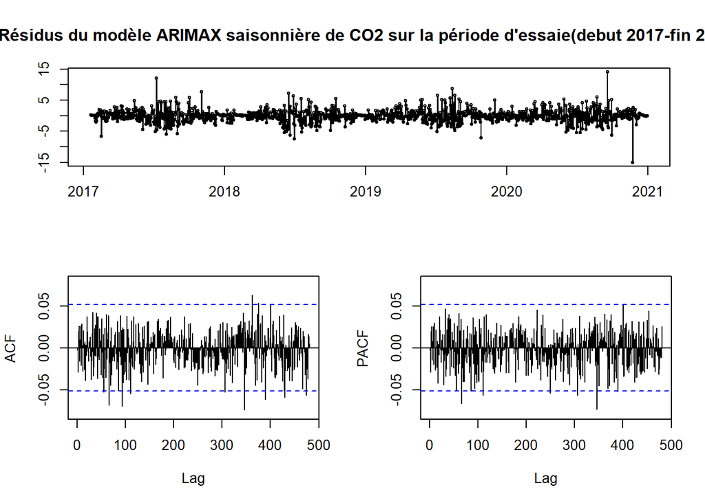

```r
# Pour CO2
tsdisplay(residuals(mod_co22), main ="Résidus du modèle ARIMAX saisonnière de CO2 sur la période d'essaie(debut 2017-fin 2020)")
```

Les autocorrelations ne nous permettent pas d’affirmer clairement que les résidus du modèlé de CO2 sont du bruit blanc à cause du faite que certains sont légèrement sortie de la bande .

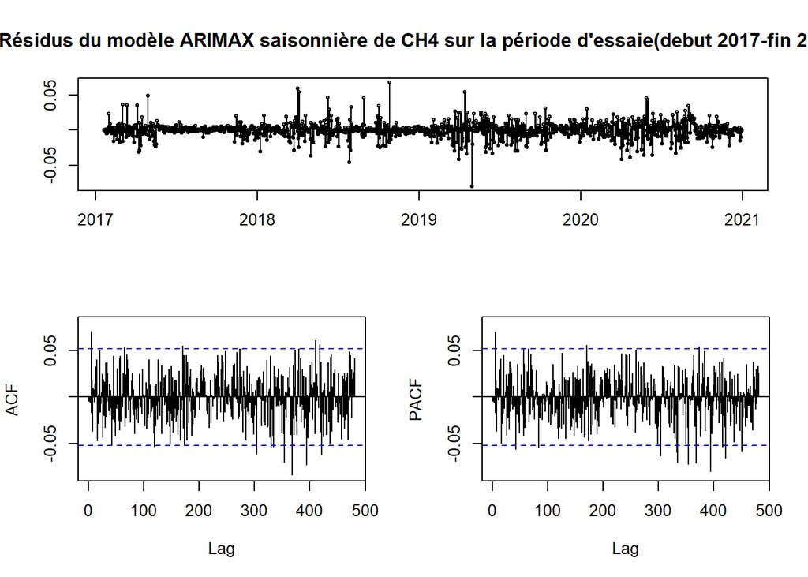

```r
# Pour CH4
tsdisplay(residuals(mod_ch44), main ="Résidus du modèle ARIMAX saisonnière de CH4 sur la période d'essaie(debut 2017-fin 2020)")
```

Les autocorrelations ne nous permettent pas d’affirmer clairement que les résidus du modèlé de CH4 sont du bruit blanc à cause du faite que certains sont légèrement sortie de la bande .

#### Test de blancheur

Faisons un test pour vérifier si les résidus sont du bruit blanc ou pas sous les hypothèses

```
   H0 :"les résidus ne sont pas autocorrélés (→ c’est du bruit blanc)" contre
   H1 :"(alternative) : les résidus sont autocorrélés (→ modèle mal ajusté") au niveau de risque 5%
```

```r
# Pour CO2
Box.test(residuals(mod_co22), lag = 30, type = "Ljung-Box")
```

```
##
##  Box-Ljung test
##
## data:  residuals(mod_co22)
## X-squared = 17.218, df = 30, p-value = 0.9699
```

En ce qui concerne le test de blancheur, la p-valeur est supérieure à alpha(0.05), donc on ne rejette pas HO (les résidus sont du bruit blancs) et donc on peut affirmer que résidus du modèle de CO2 sont du bruit blanc

```r
# Pour CH4
Box.test(residuals(mod_ch44), lag = 30, type = "Ljung-Box")
```

```
##
##  Box-Ljung test
##
## data:  residuals(mod_ch44)
## X-squared = 30.588, df = 30, p-value = 0.4359
```

En ce qui concerne le test de blancheur, la p-valeur est supérieure à alpha(0.05), donc on ne rejette pas HO (les résidus sont du bruit blancs) et donc on peut affirmer que résidus du modèle de CH4 sont du bruit blanc

#### Prévision

```r
library(forecast)
```

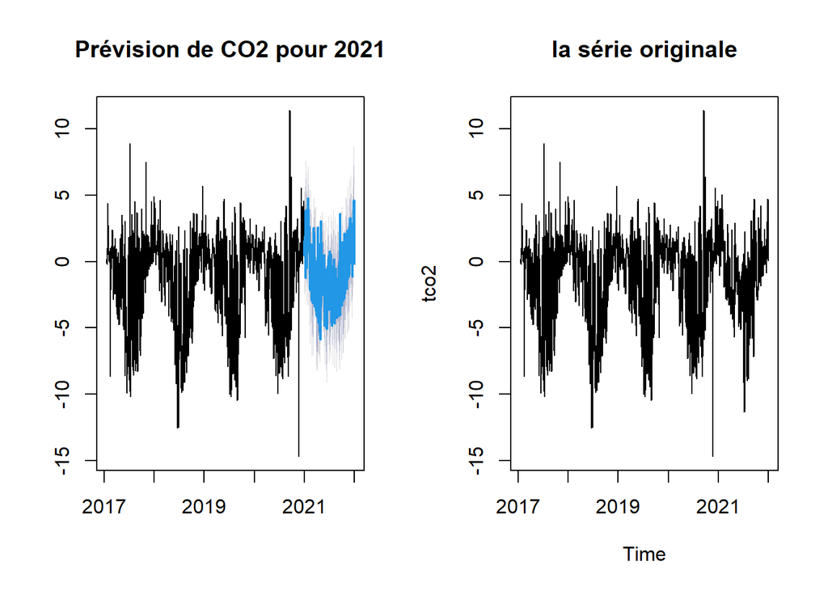

```r
# Prédire CO2 sur 2021

par(mfrow=c(1,2))

pred_co2 <- forecast(mod_co22, h = 365, xreg = reg1_test) # h=365 tout l'année de 2021
plot(pred_co2, main = "Prévision de CO2 pour 2021")
plot(tco2,main="la série originale" )
```

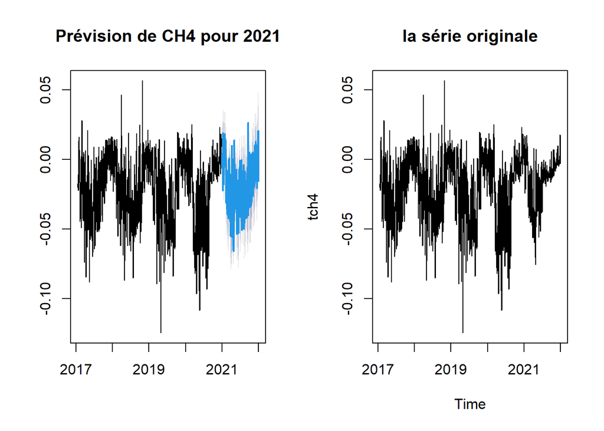

```r
# Prédire CH4 pour 2021

par(mfrow=c(1,2))

pred_ch4 <- forecast(mod_ch44, h = 365, xreg = reg2_test) # h=365 tout l'année de 2021
plot(pred_ch4, main = "Prévision de CH4 pour 2021")
plot(tch4,main="la série originale" )
```

Ces deux nous permettrons de faire une prédiction sur un long horizon en considérant les phénomènes caniculaires et de covid

#### Verifions numériquement si les modèles obtenus sont de bons modèles

##### Pour CO2

```r
mean(tco2); sd(tco2)
```

```
## [1] -1.212604
```

```
## [1] 3.239895
```

```r
accuracy(mod_co22)[, "RMSE"] # racine de l'erreur quadratique moyenne
```

```
## [1] 1.928631
```

```r
accuracy(mod_co22)[, "RMSE"] /sd(tco2)
```

```
## [1] 0.5952757
```

```r
accuracy(mod_co22)[, "RMSE"] /abs(mean(tco2))
```

```
## [1] 1.590486
```

RMSE<Ecart-type : le modèle obtenue pour CO2 explique une part significative de la variabilité Mais RMSE est sensiblement superieure à la moyenne,ce qui indique que le modèle est correct, mais pas très précis.

##### Pour CH4

```r
mean(tch4); sd(tch4)
```

```
## [1] -0.0201321
```

```
## [1] 0.02354836
```

```r
accuracy(mod_ch44)[, "RMSE"] # racine de l'erreur quadratique moyenne
```

```
## [1] 0.01064415
```

```r
accuracy(mod_ch44)[, "RMSE"] /sd(tch4)
```

```
## [1] 0.4520126
```

```r
accuracy(mod_ch44)[, "RMSE"] /abs(mean(tch4))
```

```
## [1] 0.5287154
```

RMSE est inférieure à la moyenne et aussi inférieure à l’écart-type , donc le modèle obteu pour CH4 explique une bonne part de variabilité .

##### Analyse de la prévision sur 2021

-Pour CO2

```r
accuracy(tco2_test,pred_co2$mean)
```

```
##                  ME     RMSE       MAE      MPE     MAPE     ACF1 Theil's U
## Test set 0.08110749 1.585598 0.8097502 -74.5022 156.1283 0.467475 0.1901286
```

MAPE est elevée donc les données surestimées et souestimées sont nombreuses , ce qui montre que la prédiction n’est aussi bonne que ça, mais c’est mieux qu’un modèle naif(répétition de la dernière sur le futur) a cause de (Theil’s U <1)

-Pour CH4

```r
accuracy(tch4_test,pred_ch4$mean)
```

```
##                    ME       RMSE        MAE      MPE     MAPE      ACF1
## Test set -0.004220045 0.01076525 0.00724692 3.224405 87.79771 0.7010364
##          Theil's U
## Test set 0.4286489
```

MAPE est elevée donc les données surestimées et sous-estimées sont nombreuses , ce qui montre que la prédiction n’est aussi bonne que ça, mais c’est très mieux qu’un modèle naif(répétition de la dernière sur le futur) a cause de (Theil’s U <1)

- Sur CO2 jusqu’à fin 2019

```r
# Creation de données
tco2_17_19 <- window(tco2, end = c(2019, 365))  # co2 train ,données jusqu'a fin 2018
reg_17_19<-rg1[1:length(tco2_17_19),] # regresseur train, données jusqu'a fin 2018

tco2_20_21 <- window(tco2, start = c(2020, 1))  # co2 test ,données à partrir de debut 2019
reg_20_21 <- rg1[(length(tco2_17_19) + 1):(length(tco2_17_19) + length(tco2_20_21)), ]# regresseur test, données à partrir de debut 2019
```

```r
#Determination du modèle
mod_co2_17_19 <- auto.arima(tco2_17_19, xreg = reg_17_19 )
summary(mod_co2_17_19)
```

```
## Series: tco2_17_19
## Regression with ARIMA(1,0,2) errors
##
## Coefficients:
##          ar1      ma1      ma2  intercept   Axis1   Axis2   Axis3    Axis4
##       0.9526  -0.7371  -0.0807    -1.2594  0.3244  0.1758  0.7584  -0.3363
## s.e.  0.0167   0.0353   0.0328     0.2153  0.0318  0.0481  0.0285   0.0377
##
## sigma^2 = 3.474:  log likelihood = -2194.93
## AIC=4407.86   AICc=4408.03   BIC=4452.7
##
## Training set error measures:
##                         ME     RMSE      MAE       MPE     MAPE      MASE
## Training set -0.0007862922 1.856819 1.273294 -2.672984 356.8189 0.4721027
##                      ACF1
## Training set -0.001656766
```

- Sur CH4 jusqu’à fin 2019

```r
# Creation de données
tch4_17_19 <- window(tch4, end = c(2019,365 )) # co2 train ,données jusqu'a fin 2020
r_17_19<-rg2[1:length(tch4_17_19),] # regresseur train, données jusqu'a fin 2020

tch4_20_21 <- window(tch4, start = c(2020, 1))  # co2 test ,données à partrir de debut 2018
r_20_21 <- rg2[(length(tch4_17_19) + 1):(length(tch4_17_19) + length(tch4_20_21)), ]# regresseur test, données à partrir de debut 2018
```

```r
# pour CH4
mod_ch4_17_19 <- auto.arima(tch4_17_19, xreg = r_17_19 )
summary(mod_ch4_17_19)
```

```
## Series: tch4_17_19
## Regression with ARIMA(1,0,2) errors
##
## Coefficients:
##          ar1      ma1      ma2  intercept  Axis1   Axis2   Axis3    Axis4
##       0.8801  -0.6836  -0.0676    -0.0207  2e-03  0.0014  0.0063  -0.0046
## s.e.  0.0505   0.0592   0.0384     0.0006  1e-04  0.0002  0.0002   0.0002
##
## sigma^2 = 0.0001053:  log likelihood = 3407.57
## AIC=-6797.15   AICc=-6796.98   BIC=-6752.31
##
## Training set error measures:
##                        ME       RMSE         MAE      MPE     MAPE      MASE
## Training set -7.37324e-07 0.01022463 0.006196506 53.09046 136.8994 0.2905674
##                      ACF1
## Training set -0.001127911
```

##### Test de blancheurs sur les residus des modèles avant 2020 retenus

-Pour CO2

```r
Box.test(residuals(mod_co2_17_19), lag = 30, type = "Ljung-Box")
```

```
##
##  Box-Ljung test
##
## data:  residuals(mod_co2_17_19)
## X-squared = 20.7, df = 30, p-value = 0.897
```

En ce qui concerne le test de blancheur, la p-valeur est supérieure à alpha(0.05), donc on ne rejette pas HO (les résidus sont du bruit blancs) et donc on peut affirmer que résidus du modèle de CO2 sont du bruit blanc

-Pour CH4

```r
Box.test(residuals(mod_ch4_17_19), lag = 30, type = "Ljung-Box")
```

```
##
##  Box-Ljung test
##
## data:  residuals(mod_ch4_17_19)
## X-squared = 32.673, df = 30, p-value = 0.3369
```

##### Faisons une prevision sur 2020-2021

-Pour CO2

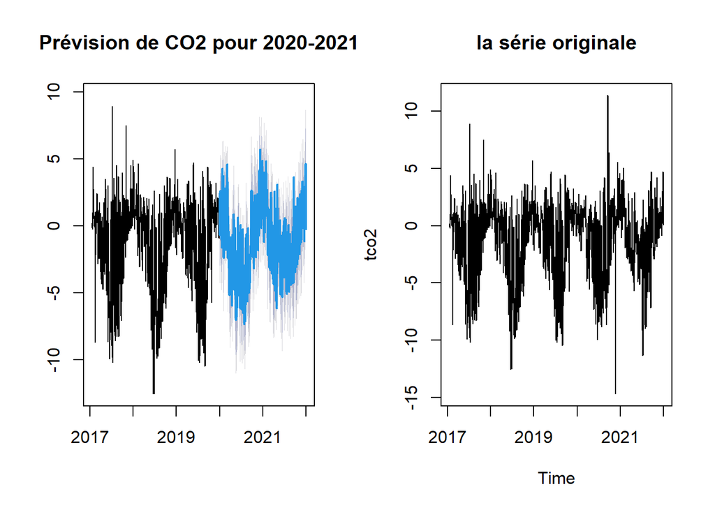

```r
# Prédire CO2 sur 2020-2021

par(mfrow=c(1,2))

pred_co2_20_21 <- forecast(mod_co2_17_19, h = 365*2, xreg =reg_20_21  ) # h=365*4 tout l'année 2019-2021

plot(pred_co2_20_21, main = "Prévision de CO2 pour 2020-2021")
plot(tco2,main="la série originale" )
```

- Pour CH4

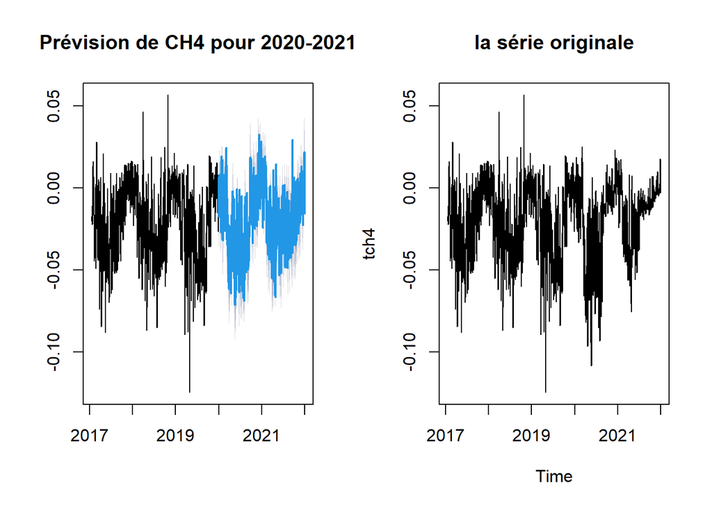

```r
# Prédire CH4 sur 2018-2021

par(mfrow=c(1,2))

pred_ch4_20_21 <- forecast(mod_ch4_17_19, h = 365*2, xreg =r_20_21  ) # toute l'année 2020-2021

plot(pred_ch4_20_21, main = "Prévision de CH4 pour 2020-2021")
plot(tch4,main="la série originale" )
```

Visuellement , on vois que les prévision sont bonne a cause de la dynamique et les saisonnalité qui sont concerver

#### Analysons la qualité de prédiction

```r
accuracy(tco2_20_21,pred_co2_20_21$mean)
```

```
##                  ME     RMSE      MAE       MPE     MAPE      ACF1 Theil's U
## Test set -0.1182317 1.927408 1.139291 -53.63164 217.0468 0.2932583 0.7288718
```

L’Erreur Moyenne Absolue en Pourcentage (MAPE) est élévée, ce qui montre qu’on a plus d’erreur que de bonne valeur dans la prediction

(Plus de detail sur MAPE a faire dans le rapport)

```r
accuracy(tch4_20_21,pred_ch4_20_21$mean)
```

```
##                    ME       RMSE        MAE      MPE     MAPE      ACF1
## Test set -0.001433799 0.01239023 0.00834926 21.65624 80.21857 0.5680503
##          Theil's U
## Test set 0.6093122
```

L’Erreur Moyenne Absolue en Pourcentage (MAPE) est un peu élévée, ce qui montre qu’on a un peu d’erreur que de bonne valeur dans la prédiction. Les autres indicateurs montrent que le modèle est bon, mais aussi perfectible.

##### Comparaison des prévisions des deux modèles précédents sur 2021

-CO2

```r
# Extraire les donnees de 2021 uniquement
tco2_2021 <- window(tco2_20_21, start = c(2021, 1), end = c(2021, 365))
pred_co2_2021 <- window(pred_co2_20_21$mean, start = c(2021, 1), end = c(2021, 365))

accuracy(tco2_2021, pred_co2_2021)
```

```
##                    ME     RMSE       MAE      MPE     MAPE      ACF1 Theil's U
## Test set -0.001575472 1.587136 0.8501405 44.82884 116.1839 0.4660409 0.3562836
```

-CH4

```r
tch4_2021 <- window(tch4_20_21, start = c(2021, 1), end = c(2021, 365))
pred_ch4_2021 <- window(pred_ch4_20_21$mean, start = c(2021, 1), end = c(2021, 365))

accuracy(tch4_2021, pred_ch4_2021)
```

```
##                    ME       RMSE         MAE      MPE     MAPE      ACF1
## Test set -0.004068674 0.01069048 0.007143127 37.89908 73.69782 0.6845236
##          Theil's U
## Test set  1.041732
```

#### Modèle 3 : Sans regresseurs

-Training set

```r
# Pour CO2
tco2_train <- window(tco2, end = c(2020, 365))  # co2 train ,données jusqu'a fin 2020


# Pour CH4
tch4_train <- window(tch4, end = c(2020, 365)) # co2 train ,données jusqu'a fin 2020
```

-Test set

```r
# Pour CO2
tco2_test <- window(tco2, start = c(2021, 1))  # co2 test ,données à partrir de debut 2021

# Pour CH4
tch4_test <- window(tch4, start = c(2021, 1))  # ch4 test ,données à partrir de debut 2021
```

-Modelisation

```r
# pour CO2
mod_co2_sr <- auto.arima(tco2_train )
summary(mod_co2_sr)
```

```
## Series: tco2_train
## ARIMA(2,0,1) with zero mean
##
## Coefficients:
##          ar1      ar2      ma1
##       1.2089  -0.2183  -0.8694
## s.e.  0.0353   0.0337   0.0212
##
## sigma^2 = 6.167:  log likelihood = -3356.97
## AIC=6721.95   AICc=6721.97   BIC=6743.04
##
## Training set error measures:
##                       ME     RMSE     MAE      MPE     MAPE      MASE
## Training set -0.08244551 2.480834 1.75013 50.81721 335.8661 0.6716219
##                      ACF1
## Training set -0.005145006
```

Le modèle de CO2 sans regresseur est stationnaire

```r
# pour CH4
mod_ch4_sr <- auto.arima(tch4_train )
summary(mod_ch4_sr)
```

```
## Series: tch4_train
## ARIMA(4,0,1) with non-zero mean
##
## Coefficients:
##          ar1      ar2     ar3      ar4      ma1     mean
##       1.2870  -0.2342  0.0015  -0.0623  -0.9002  -0.0212
## s.e.  0.0353   0.0437  0.0429   0.0292   0.0229   0.0054
##
## sigma^2 = 0.0002945:  log likelihood = 3818.12
## AIC=-7622.25   AICc=-7622.17   BIC=-7585.33
##
## Training set error measures:
##                        ME       RMSE        MAE      MPE     MAPE      MASE
## Training set 7.331889e-05 0.01712617 0.01282145 42.54727 282.6952 0.5968061
##                      ACF1
## Training set 0.0003843698
```

Le modèle de CH4 sans regresseur est stationnaire, ce qui nous amène à dire que la non-stationnarité du modèle avec regresseur est liée aux regresseurs

-Prevision sur 2021

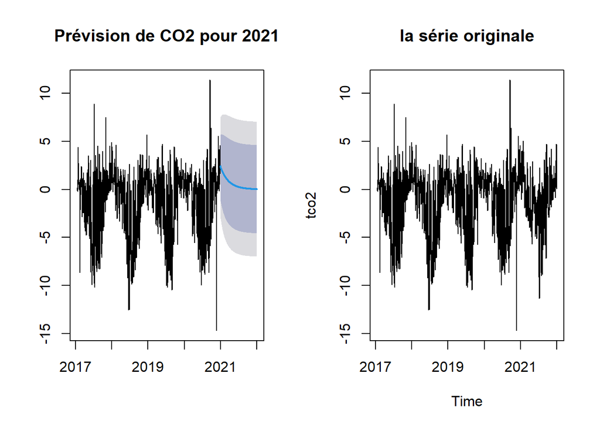

```r
# Prédire CO2 sur 2021

par(mfrow=c(1,2))

pred_co2_sr <- forecast(mod_co2_sr, h = 365) # h=365 toute l'année de 2021
plot(pred_co2_sr, main = "Prévision de CO2 pour 2021")
plot(tco2,main="la série originale" )
```

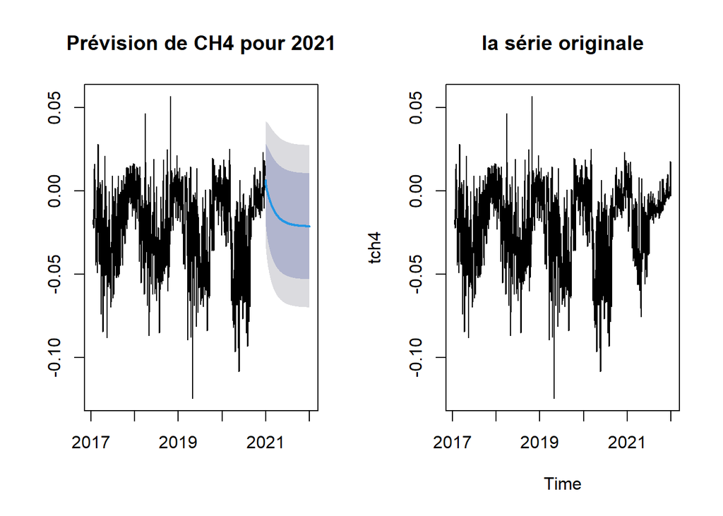

```r
# Prédire CH4 pour 2021

par(mfrow=c(1,2))

pred_ch4_sr <- forecast(mod_ch4_sr, h = 365, xreg = reg2_test) # h=365 tout l'année de 2021
plot(pred_ch4_sr, main = "Prévision de CH4 pour 2021")
plot(tch4,main="la série originale" )
```

# Analysons la qualité de prediction sur 2021, du modèle sans regresseur

-Pour CO2

```r
accuracy(tco2_test,pred_co2_sr$mean)
```

```
##                ME     RMSE      MAE      MPE     MAPE      ACF1 Theil's U
## Test set 1.501395 2.966081 2.199363 313.9613 1292.679 0.6294474  1728.967
```

-Pour CH4

```r
accuracy(tch4_test,pred_ch4_sr$mean)
```

```
##                    ME       RMSE        MAE      MPE     MAPE      ACF1
## Test set -0.001254271 0.01851504 0.01540639 17.82594 197.3361 0.7928543
##          Theil's U
## Test set   23.8364
```

Ici, les Theil’s U des previsions de CO2 et CH2 sont très élevées par rapport aux modèle avec regresseurs, donc les modèles avec regresseurs sont mieux .

#### Superposition des données prédites sur les observées des deux premières modèles

###### Prévision sur 2020-2021

- Pour CO2

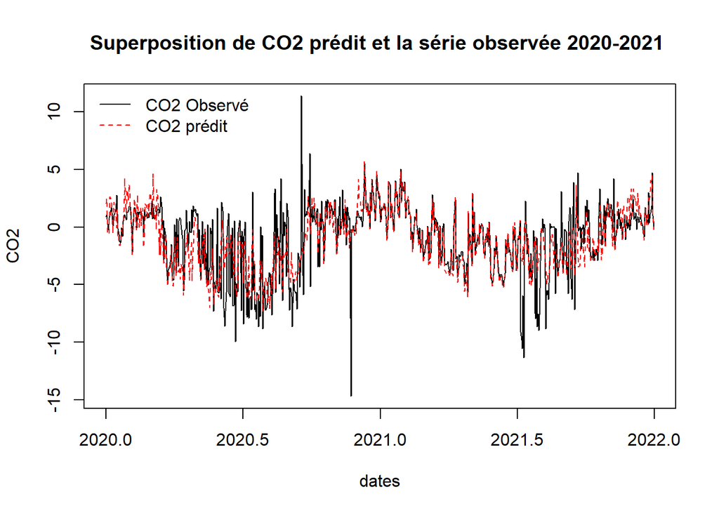

```r
tco2_20_21 <- window(tco2, start = c(2020, 1))
matrix_1<-cbind(tco2_20_21,pred_co2_20_21$mean) #,pred_co2_19_21$upper,pred_co2_19_21$lower)

plot(matrix_1,
     plot.type = "single",
     lty = c(1,2),          # Types de lignes : continue, pointillée, pointillée
     col = c("black","red"),  # Couleurs : original, borne inférieure, borne supérieure
     xlab = "dates",
     ylab = "CO2",
     main = "Superposition de CO2 prédit et la série observée 2020-2021 ",
     cex.main = 1.2)

legend(par("usr")[1],par("usr")[4],
       legend = c("CO2 Observé","CO2 prédit"),
       col = c("black","red"),
       lty = c(1,2),lwd=1,
       bty = "n")
```

On voit ici que la superposistion n’est pas bien faite.Donc sans les chiffres, on peut dire que la prévision n’est pas bonne avec ce modèle .

-Pour CH4

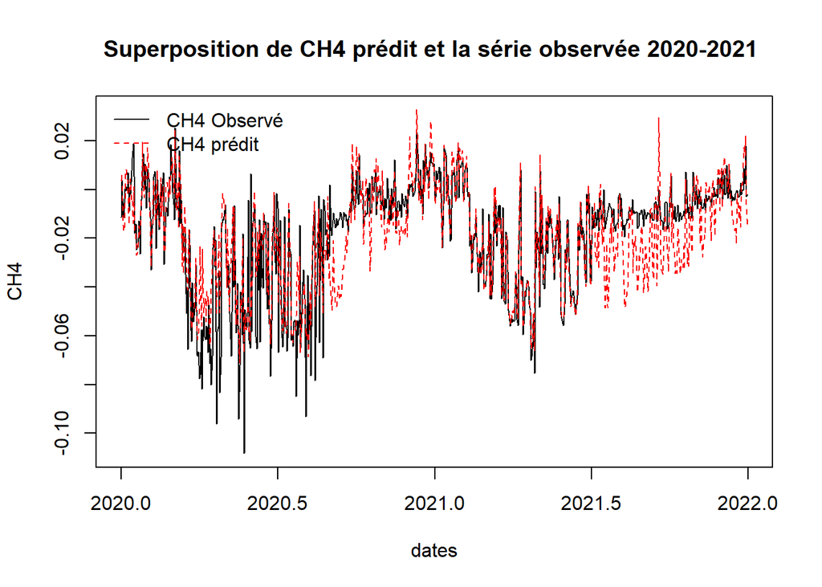

```r
tch4_20_21 <- window(tch4, start = c(2020, 1))
matrix_2<-cbind(tch4_20_21,pred_ch4_20_21$mean) #,pred_co2_19_21$upper,pred_co2_19_21$lower)

plot(matrix_2,
     plot.type = "single",
     lty = c(1,2),          # Types de lignes : continue, pointillée, pointillée
     col = c("black","red"),  # Couleurs : original, borne inférieure, borne supérieure
     xlab = "dates",
     ylab = "CH4",
     main = "Superposition de CH4 prédit et la série observée 2020-2021 ",
     cex.main = 1.2)

legend(par("usr")[1],par("usr")[4],
       legend = c("CH4 Observé","CH4 prédit"),
       col = c("black","red"),
       lty = c(1,2),lwd=1,
       bty = "n")
```

Ici aussi, on voit que la superposistion n’est pas bien faite.Donc sans les chiffres, on peut dire que la prévision n’est pas bonne avec ce modèle et ça ce fait plus remarqué en 2021 .

###### Prévision sur 2021

- Pour CO2

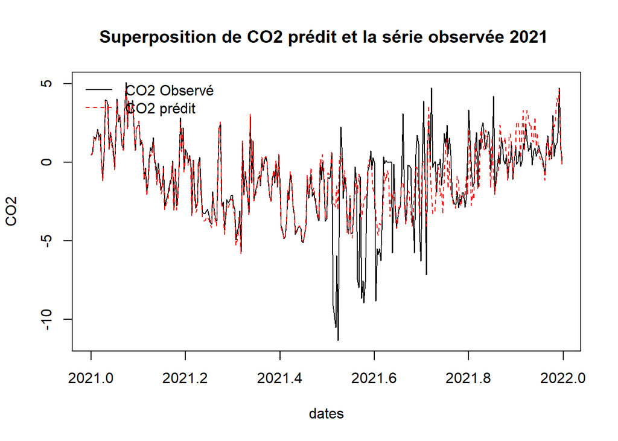

```r
tco2_21 <- window(tco2, start = c(2021, 1))
matrix_3<-cbind(tco2_21,pred_co2$mean) #,pred_co2_19_21$upper,pred_co2_19_21$lower)

plot(matrix_3,
     plot.type = "single",
     lty = c(1,2),          # Types de lignes : continue, pointillée, pointillée
     col = c("black","red"),  # Couleurs : original, borne inférieure, borne supérieure
     xlab = "dates",
     ylab = "CO2",
     main = "Superposition de CO2 prédit et la série observée 2021 ",
     cex.main = 1.2)

legend(par("usr")[1],par("usr")[4],
       legend = c("CO2 Observé","CO2 prédit"),
       col = c("black","red"),
       lty = c(1,2),lwd=1,
       bty = "n")
```

La prévision de CO2 de ce modèle(2017-2020) semble être mieux sur 2021 que celle du modèle(2017-2019). Mais n’est pas bien superposé

-Pour CH4

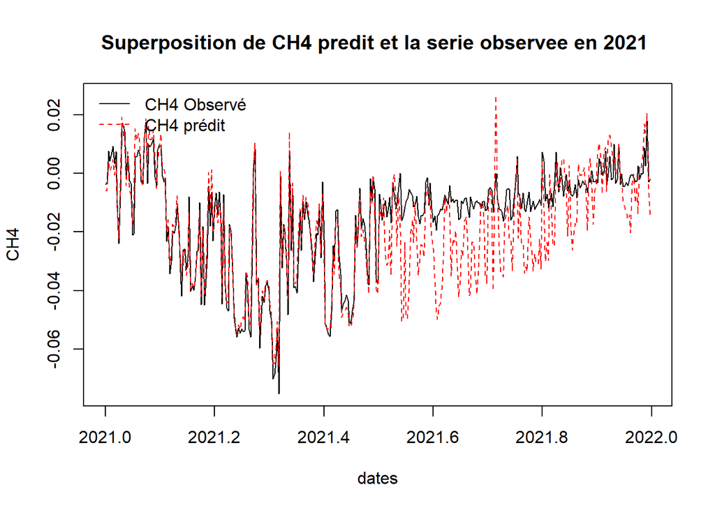

```r
tch4_21 <- window(tch4, start = c(2021, 1))
matrix_4<-cbind(tch4_21,pred_ch4$mean) #,pred_co2_19_21$upper,pred_co2_19_21$lower)

plot(matrix_4,
     plot.type = "single",
     lty = c(1,2),          # Types de lignes : continue, pointillée, pointillée
     col = c("black","red"),  # Couleurs : original, borne inférieure, borne supérieure
     xlab = "dates",
     ylab = "CH4",
     main = "Superposition de CH4 predit et la serie observee en 2021 ",
     cex.main = 1.2)

legend(par("usr")[1],par("usr")[4],
       legend = c("CH4 Observé","CH4 prédit"),
       col = c("black","red"),
       lty = c(1,2),lwd=1,
       bty = "n")
```

Voyant ça,on remarque que la superposition n’est toujours pas bien faite, et il semble que ce modèle est pire que celui conçu sur 2017-2019

### Modèle 4 : Se basant uniquement sur les années avant l’année de secheresse(2019)

-CO2

```r
# Creation de données
tco2_17_18 <- window(tco2, end = c(2018, 365))  # co2 train ,données jusqu'a fin 2018
reg1_17_18<-rg1[1:length(tco2_17_18),] # regresseur train, données jusqu'a fin 2018

tco2_19_21 <- window(tco2, start = c(2019, 1))  # co2 test ,données à partrir de debut 2019
reg1_19_21 <- rg1[(length(tco2_17_18) + 1):(length(tco2_17_18) + length(tco2_19_21)), ]# regresseur test, données à partrir de debut 2019
```

```r
#Determination du modèle
mod_co2_17_18 <- auto.arima(tco2_17_18, xreg = reg1_17_18 )
summary(mod_co2_17_18)
```

```
## Series: tco2_17_18
## Regression with ARIMA(0,1,2) errors
##
## Coefficients:
##           ma1      ma2   Axis1   Axis2   Axis3    Axis4
##       -0.8026  -0.0581  0.2229  0.4439  0.7950  -0.3570
## s.e.   0.0374   0.0393  0.0659  0.1034  0.0349   0.0483
##
## sigma^2 = 3.516:  log likelihood = -1453.45
## AIC=2920.89   AICc=2921.05   BIC=2952.86
##
## Training set error measures:
##                        ME     RMSE      MAE      MPE     MAPE      MASE
## Training set -0.006336203 1.865766 1.310771 23.69622 351.6765 0.4598496
##                       ACF1
## Training set -0.0004444932
```

-CH4

```r
# Creation de données
tch4_17_18 <- window(tch4, end = c(2018,365 )) # co2 train
reg2_17_18<-rg2[1:length(tch4_17_18),] # regresseur train,

tch4_19_21 <- window(tch4, start = c(2019, 1))  # co2 test ,données à partrir de debut 2018
reg2_19_21 <- rg2[(length(tch4_17_18) + 1):(length(tch4_17_18) + length(tch4_19_21)), ]# regresseur test, données à partrir de debut 2018
```

```r
# pour CH4
mod_ch4_17_18 <- auto.arima(tch4_17_18, xreg = reg2_17_18 )
summary(mod_ch4_17_18)
```

```
## Series: tch4_17_18
## Regression with ARIMA(2,0,2) errors
##
## Coefficients:
##           ar1     ar2     ma1      ma2  intercept   Axis1   Axis2   Axis3
##       -0.1980  0.6959  0.3837  -0.5662    -0.0182  0.0017  0.0027  0.0065
## s.e.   0.0928  0.0795  0.1051   0.0968     0.0007  0.0001  0.0003  0.0002
##         Axis4
##       -0.0048
## s.e.   0.0002
##
## sigma^2 = 8.723e-05:  log likelihood = 2321.68
## AIC=-4623.36   AICc=-4623.05   BIC=-4577.68
##
## Training set error measures:
##                        ME        RMSE         MAE      MPE     MAPE      MASE
## Training set 3.244458e-08 0.009280281 0.005286634 52.12615 115.5318 0.2372578
##                     ACF1
## Training set 0.001944338
```

-Prevision -CO2

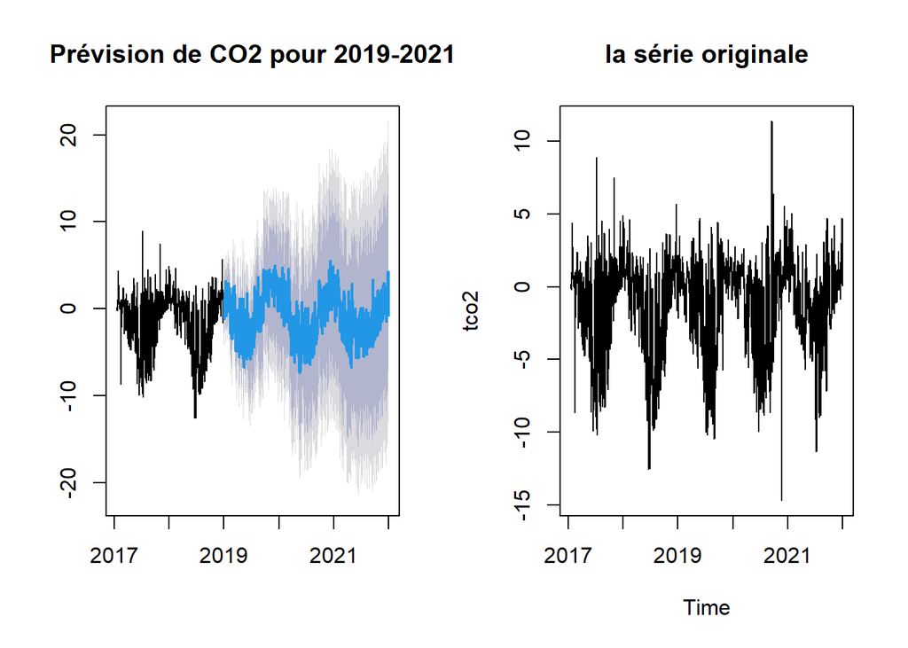

```r
# Prédire CO2 sur 2019-2021

par(mfrow=c(1,2))

pred_co2_19_21 <- forecast(mod_co2_17_18, h = 365*3, xreg =reg1_19_21  ) # h=365*4 tout l'année 2019-2021

plot(pred_co2_19_21, main = "Prévision de CO2 pour 2019-2021")
plot(tco2,main="la série originale" )
```

-CH4

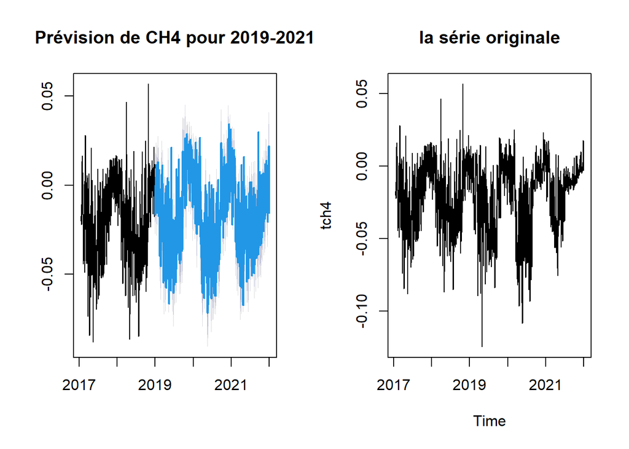

```r
# Prédire CH4 sur 2019-2021

par(mfrow=c(1,2))

pred_ch4_19_21 <- forecast(mod_ch4_17_18, h = 365*3, xreg =reg2_19_21  ) # h=365*4 tout l'année 2019-2021

plot(pred_ch4_19_21, main = "Prévision de CH4 pour 2019-2021")
plot(tch4,main="la série originale" )
```

##### Qualité de prevision

```r
accuracy(tco2_19_21,pred_co2_19_21$mean)
```

```
##                 ME     RMSE      MAE      MPE     MAPE     ACF1 Theil's U
## Test set 0.2116387 2.369391 1.634029 17.54809 212.5948 0.518713   1.02775
```

```r
accuracy(tch4_19_21,pred_ch4_19_21$mean)
```

```
##                   ME       RMSE        MAE      MPE     MAPE      ACF1
## Test set 0.003131542 0.01379919 0.00965951 8.406173 139.6266 0.5514428
##          Theil's U
## Test set  1.046124
```

#### Superposition des données prédites sur les observées des deux modèles

###### Prévision sur 2019-2021

- Pour CO2

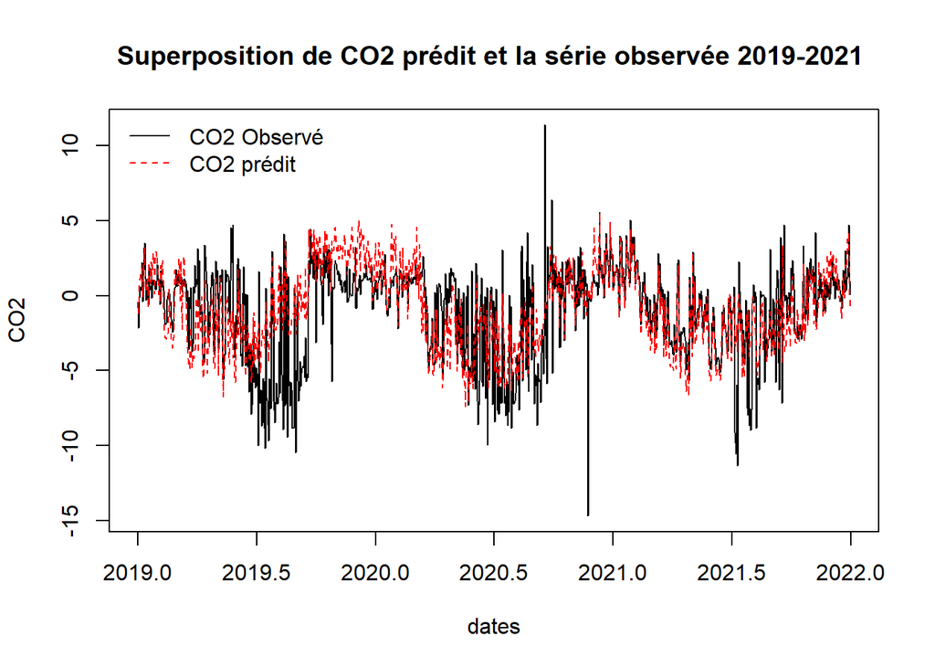

```r
tco2_19_21 <- window(tco2, start = c(2019, 1))
matrix_7<-cbind(tco2_19_21,pred_co2_19_21$mean) #,pred_co2_19_21$upper,pred_co2_19_21$lower)

plot(matrix_7,
     plot.type = "single",
     lty = c(1,2),          # Types de lignes : continue, pointillée, pointillée
     col = c("black","red"),  # Couleurs : original, borne inférieure, borne supérieure
     xlab = "dates",
     ylab = "CO2",
     main = "Superposition de CO2 prédit et la série observée 2019-2021 ",
     cex.main = 1.2)

legend(par("usr")[1],par("usr")[4],
       legend = c("CO2 Observé","CO2 prédit"),
       col = c("black","red"),
       lty = c(1,2),lwd=1,
       bty = "n")
```

-Pour CH4

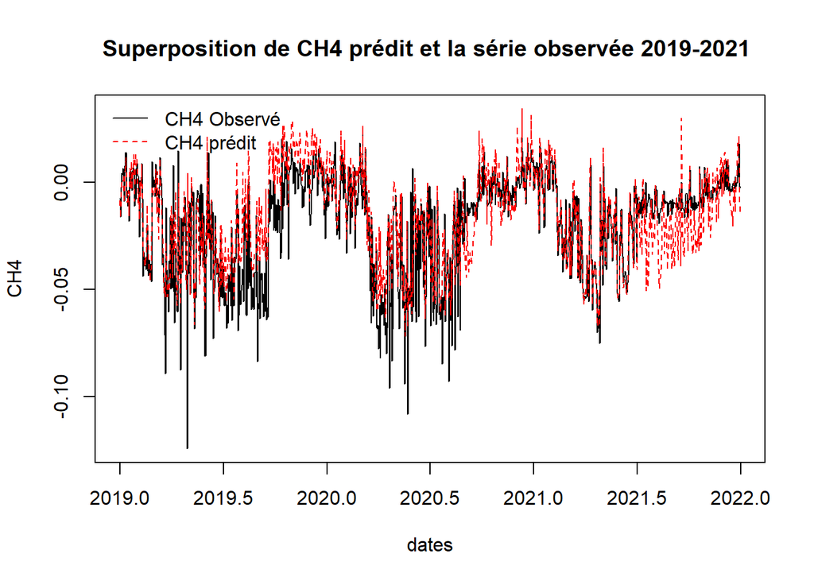

```r
tch4_20_21 <- window(tch4, start = c(2019, 1))
matrix_8<-cbind(tch4_19_21,pred_ch4_19_21$mean) #,pred_co2_19_21$upper,pred_co2_19_21$lower)

plot(matrix_8,
     plot.type = "single",
     lty = c(1,2),          # Types de lignes : continue, pointillée, pointillée
     col = c("black","red"),  # Couleurs : original, borne inférieure, borne supérieure
     xlab = "dates",
     ylab = "CH4",
     main = "Superposition de CH4 prédit et la série observée 2019-2021 ",
     cex.main = 1.2)

legend(par("usr")[1],par("usr")[4],
       legend = c("CH4 Observé","CH4 prédit"),
       col = c("black","red"),
       lty = c(1,2),lwd=1,
       bty = "n")
```

###### Prévision sur 2021

- Pour CO2

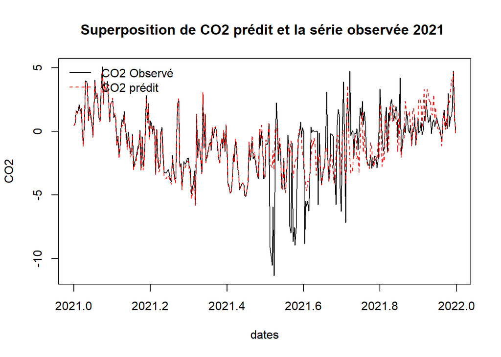

```r
tco2_21 <- window(tco2, start = c(2021, 1))
matrix_9<-cbind(tco2_21,pred_co2$mean) #,pred_co2_19_21$upper,pred_co2_19_21$lower)

plot(matrix_9,
     plot.type = "single",
     lty = c(1,2),          # Types de lignes : continue, pointillée, pointillée
     col = c("black","red"),  # Couleurs : original, borne inférieure, borne supérieure
     xlab = "dates",
     ylab = "CO2",
     main = "Superposition de CO2 prédit et la série observée 2021 ",
     cex.main = 1.2)

legend(par("usr")[1],par("usr")[4],
       legend = c("CO2 Observé","CO2 prédit"),
       col = c("black","red"),
       lty = c(1,2),lwd=1,
       bty = "n")
```

-Pour CH4

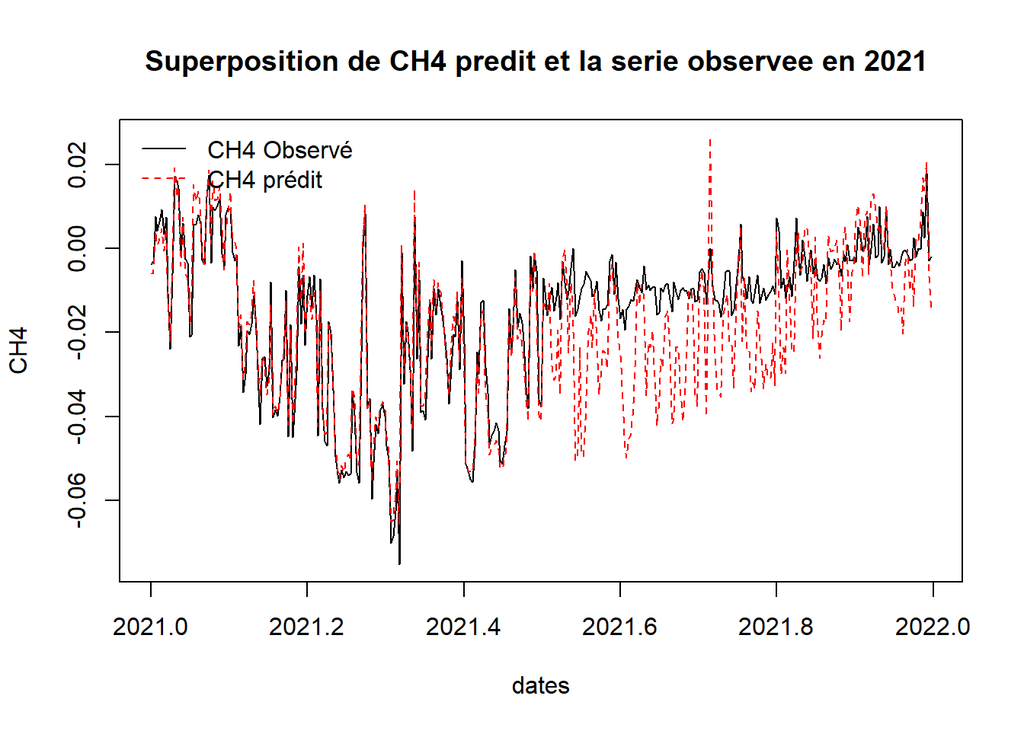

```r
tch4_21 <- window(tch4, start = c(2021, 1))
matrix_10<-cbind(tch4_21,pred_ch4$mean) #,pred_co2_19_21$upper,pred_co2_19_21$lower)

plot(matrix_10,
     plot.type = "single",
     lty = c(1,2),          # Types de lignes : continue, pointillée, pointillée
     col = c("black","red"),  # Couleurs : original, borne inférieure, borne supérieure
     xlab = "dates",
     ylab = "CH4",
     main = "Superposition de CH4 predit et la serie observee en 2021 ",
     cex.main = 1.2)

legend(par("usr")[1],par("usr")[4],
       legend = c("CH4 Observé","CH4 prédit"),
       col = c("black","red"),
       lty = c(1,2),lwd=1,
       bty = "n")
```

##### Voyons maintenant la qualité de prevision des 3 modèles sur 2021

Pour le modèle de 2017-2020

-Pour CO2

```r
accuracy(tco2_test,pred_co2$mean)
```

```
##                  ME     RMSE       MAE      MPE     MAPE     ACF1 Theil's U
## Test set 0.08110749 1.585598 0.8097502 -74.5022 156.1283 0.467475 0.1901286
```

-Pour CH4

```r
accuracy(tch4_test,pred_ch4$mean)
```

```
##                    ME       RMSE        MAE      MPE     MAPE      ACF1
## Test set -0.004220045 0.01076525 0.00724692 3.224405 87.79771 0.7010364
##          Theil's U
## Test set 0.4286489
```

Pour le modèle de 2017-2019

-CO2

```r
# Extraire les donnees de 2021 uniquement
tco2_21 <- window(tco2_19_21, start = c(2021, 1), end = c(2021, 365))
pred_co2_2021 <- window(pred_co2_20_21$mean, start = c(2021, 1), end = c(2021, 365))

accuracy(tco2_21, pred_co2_2021)
```

```
##                    ME     RMSE       MAE      MPE     MAPE      ACF1 Theil's U
## Test set -0.001575472 1.587136 0.8501405 44.82884 116.1839 0.4660409 0.3562836
```

-CH4

```r
tch4_2021 <- window(tch4_19_21, start = c(2021, 1), end = c(2021, 365))
pred_ch4_2021 <- window(pred_ch4_20_21$mean, start = c(2021, 1), end = c(2021, 365))

accuracy(tch4_2021, pred_ch4_2021)
```

```
##                    ME       RMSE         MAE      MPE     MAPE      ACF1
## Test set -0.004068674 0.01069048 0.007143127 37.89908 73.69782 0.6845236
##          Theil's U
## Test set  1.041732
```

Pour le modèle de 2017-2018

-CO2

```r
# Extraire les donnees de 2021 uniquement
tco2_21 <- window(tco2_19_21, start = c(2021, 1), end = c(2021, 365))
pred_co2_2021 <- window(pred_co2_19_21$mean, start = c(2021, 1), end = c(2021, 365))

accuracy(tco2_21, pred_co2_2021)
```

```
##                 ME     RMSE      MAE      MPE     MAPE      ACF1 Theil's U
## Test set -0.316652 1.632162 1.053335 38.27849 170.0816 0.4612287 0.3791752
```

-CH4

```r
tch4_21 <- window(tch4_19_21, start = c(2021, 1), end = c(2021, 365))
pred_ch4_2021 <- window(pred_ch4_19_21$mean, start = c(2021, 1), end = c(2021, 365))

accuracy(tch4_21, pred_ch4_2021)
```

```
##                    ME       RMSE         MAE      MPE     MAPE      ACF1
## Test set -0.003476369 0.01036566 0.006886471 48.22541 68.84847 0.6647521
##          Theil's U
## Test set 0.5343751
```

#### Modélisation sur les données mensuelles

Tout d’abord, on finalise la création des données mensuelles des gaz à effet de serre, et en suites celui des composantes.

-Pour CO2

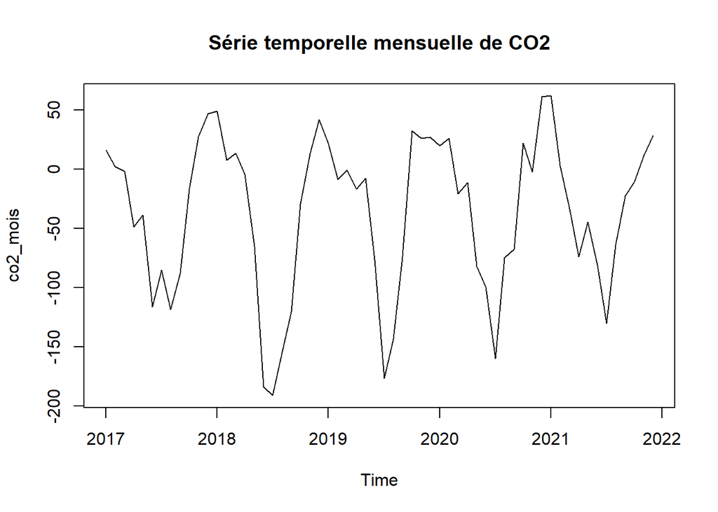

```r
co2_mois <- ts(data_mois$FCO2, start = c(2017, 1), frequency = 12)

plot(co2_mois, main = "Série temporelle mensuelle de CO2")
```

A partir de l’année 2019, on observe l’augmentation des flux de CO2 dans les mois d’été, Ce qui montre la croissance de la tendance observée sur la décomposition des données journalières

- Pour CH4

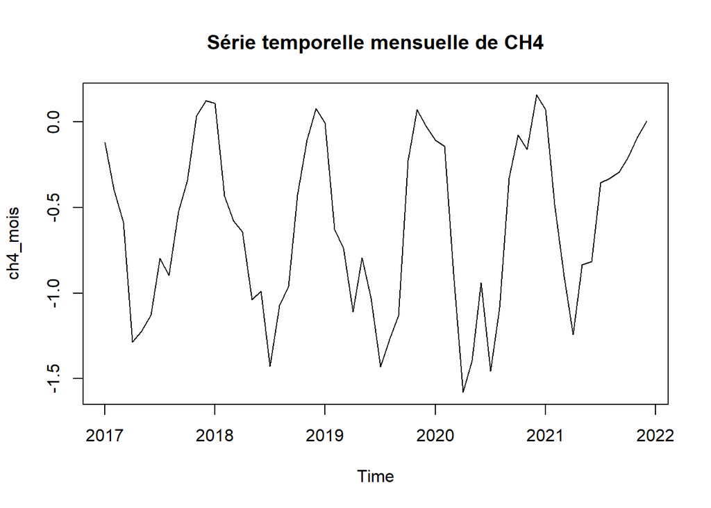

```r
ch4_mois <- ts(data_mois$FCH4, start = c(2017, 1), frequency = 12)

plot(ch4_mois, main = "Série temporelle mensuelle de CH4")
```

Ici, on observe une décroissance des flux de CH4 en été 2020, et c’est revenu presqu’au normale en 2021, ce qui justifie les analyses et conclusion faites sur le choix du modèle (2017-2018), pour la prévision de CH4 .

– Passons a la formations des composantes principales mensuelles

```r
comp <- data.frame(comp1 = acp$li[,1],comp2 = acp$li[,2],comp3 = acp$li[,3],comp4 = acp$li[,4])

# Agréger par mois en prenant la moyenne
cp_mois <- aggregate(comp, by = list(AnMois), FUN = mean)

# Renommer la première colonne
colnames(cp_mois)[1] <- "AnMois"

head(cp_mois)
```

```
##   AnMois     comp1     comp2      comp3      comp4
## 1 201701  9.319136  2.099926 -0.9027975  1.2607946
## 2 201702  6.893655 -0.447396  0.5687444  1.9828711
## 3 201703  4.273613 -1.985617  0.1996814  1.2263393
## 4 201704  2.885284 -2.276126 -2.5745387  1.1160457
## 5 201705 -1.118651 -3.967742 -0.6442247  0.3806638
## 6 201706 -6.329126 -3.053315 -0.3426851 -0.5310677
```

- Modélisation

– C02

On va tout d’abord définir le régresseur.

```r
reg_mois <- as.matrix(cp_mois[, c("comp1", "comp2", "comp3", "comp4")])
```

Ensuite à la création des données d’entrainement et test

```r
co2_mois_train <- window(co2_mois, end = c(2020, 12))
reg_mois_17_20 <- reg_mois[1:length(co2_mois_train), ]

co2_mois_test <- window(co2_mois, start = c(2021, 1))
reg_mois_21 <- reg_mois[(length(co2_mois_train)+1):length(co2_mois), ]
```

```r
mod_co2_mois <- auto.arima(co2_mois_train, xreg = reg_mois_17_20)
summary(mod_co2_mois)
```

```
## Series: co2_mois_train
## Regression with ARIMA(0,0,1)(1,0,0)[12] errors
##
## Coefficients:
##          ma1    sar1  intercept   comp1   comp2    comp3    comp4
##       0.6513  0.3711   -36.5085  9.8107  4.5263  22.9905  -4.6335
## s.e.  0.1479  0.1677     6.6730  1.0918  1.5872   2.7045   5.0391
##
## sigma^2 = 472.1:  log likelihood = -213.26
## AIC=442.52   AICc=446.21   BIC=457.49
##
## Training set error measures:
##                       ME     RMSE      MAE       MPE     MAPE      MASE
## Training set -0.06716818 20.08115 16.51001 -110.1387 134.6743 0.5318801
##                     ACF1
## Training set -0.04262262
```

-Le modèle capture la saisonnalité annuelle grâce à l’AR saisonnier et l’effet dynamique grâce à MA1. -Les composantes principales, surtout comp3 et comp1, apportent une bonne partie de l’explication de la tendance et de la variabilité mensuelle. -Le MAPE élevé montre qu’il reste une variabilité difficile à prédire.

et l’équation du processus retenu par le modèle est : $(1−0.3711B12)y_t=−36.51+9.81comp1_t+4.53comp2_t+22.99comp3_t−4.63comp4_t+(1+0.6513B)ε_t$

— Vérifions la nature des residus avec le test de blancheur

```r
Box.test(residuals(mod_co2_mois), lag = 30, type = "Ljung-Box")
```

```
##
##  Box-Ljung test
##
## data:  residuals(mod_co2_mois)
## X-squared = 30.166, df = 30, p-value = 0.4572
```

le resultat de ce test nous amène à accepter la blancheur des residus.

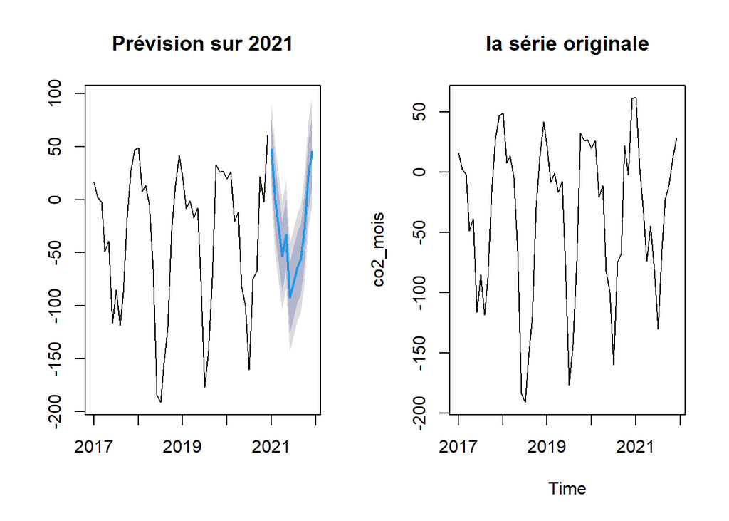

```r
par(mfrow=c(1,2))

pred_co2_mois <- forecast(mod_co2_mois,h=365, xreg = reg_mois_21)


plot(pred_co2_mois, main = "Prévision sur 2021")
plot(co2_mois,main="la série originale" )
```

La prévision sur 2021 suit la dynamique et la tendance du flux du CO2 observé préalablement avec les données journalières. Certainement, la prévision sur une longue horizon donnera la réduction progrèssive du chronogramme->plus de consommation de CO2 par la tourbière en été ->plus de sa production par les activités humaines

–CH4

Comme retenu sur la série journalière de CH4, on fait un modèle sur l’année 2017-2018 avec les données mensuelles

```r
ch4_mois_train <- window(ch4_mois, end = c(2018, 12))
reg_mois_17_18 <- reg_mois[1:length(ch4_mois_train), ]

ch4_mois_test <- window(ch4_mois, start = c(2019, 1))
reg_mois_19_21 <- reg_mois[(length(ch4_mois_train)+1):length(ch4_mois), ]
```

```r
mod_ch4_mois <- auto.arima(ch4_mois_train, xreg = reg_mois_17_18)
summary(mod_ch4_mois)
```

```
## Series: ch4_mois_train
## Regression with ARIMA(0,0,0) errors
##
## Coefficients:
##       intercept   comp1   comp2   comp3    comp4
##         -0.5409  0.0517  0.0892  0.1779  -0.1448
## s.e.     0.0209  0.0048  0.0102  0.0176   0.0253
##
## sigma^2 = 0.007723:  log likelihood = 27.11
## AIC=-42.22   AICc=-37.28   BIC=-35.15
##
## Training set error measures:
##                         ME       RMSE        MAE        MPE     MAPE      MASE
## Training set -5.372728e-15 0.07819216 0.05746823 -0.9081018 21.01701 0.2496909
##                    ACF1
## Training set -0.2281406
```

- On suppose que tout le signal est capturé par les régressseurs.
- Le coefficient le plus important en valeur absolue est pour la comp3 (+0.1779), ce qui montre que cette composante explique la plus grande part de variabilité de CH4.

Le modèle est globalement simple et explique bien la série sans dynamique résiduelle (ACF1 -0.23, pas d’autocorrélation notable). Et aussi les erreurs d’entrainement mesurées sont faible.

L’équation de cette trajectoire s’écrit comme suit :

$y_t=−0.5409+0.0517comp1_t+0.0892comp2_t+0.1779comp3_t−0.1448comp4_t+ε_t$

Vérifions donc si les residus sont gaussien avec le test de Shapiro-Wilk, vu que notre modèle ici est une regression

```r
shapiro.test(residuals(mod_ch4_mois))
```

```
##
##  Shapiro-Wilk normality test
##
## data:  residuals(mod_ch4_mois)
## W = 0.94221, p-value = 0.1826
```

On valide la normalité des residus, donc notre regression est valide.

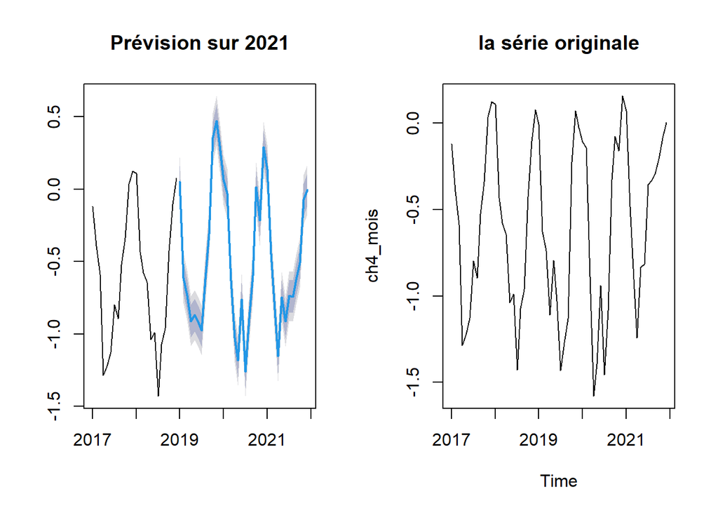

```r
par(mfrow=c(1,2))

pred_ch4_mois <- forecast(mod_ch4_mois,h=3, xreg =reg_mois_19_21 )


plot(pred_ch4_mois, main = "Prévision sur 2021")
plot(ch4_mois,main="la série originale" )
```

Ici, la prévison nous montre une augmentation de la quantité de CH4 libérés en 2019,2020, par rapport aux années précédentes,et qui revient presqu’au rythme de l’année 2017 en 2021 .